# Analyses of GSE242766

# With m6A SG vs WC

Now, I compare samples separately. First I will compare samples with m6A. Since the authors link m6A to SG enrichment and ALS, I focused on the ALS samples.

(Additionally, it appears the effect of m6A is very very light, but it appears to be slightly less so on ALS samples)

```r
mm <- model.matrix(~0+SampleColouring)
fitted <- lmFit(y, mm)
head(coef(fitted))
```

```
##          SampleColouringALSGCT SampleColouringALSGEX SampleColouringALWCCT
## A1BG-AS1              5.138619              5.532360              3.924289
## AAAS                  5.829701              5.560291              6.878930
## AACS                  6.067695              6.112001              5.914414
## AADAT                 3.746200              3.485048              4.549290
## AAGAB                 5.932453              6.006103              6.439615
## AAK1                  7.167454              7.381261              5.783071
##          SampleColouringALWCEX SampleColouringWTSGCT SampleColouringWTSGEX
## A1BG-AS1              4.514969              5.186189              5.786717
## AAAS                  6.912330              6.132604              5.942676
## AACS                  6.179367              6.218344              6.372440
## AADAT                 4.388452              3.756218              3.819003
## AAGAB                 6.145710              5.675714              5.670981
## AAK1                  5.912785              7.109989              7.158979
##          SampleColouringWTWCCT SampleColouringWTWCEX
## A1BG-AS1              4.175228              4.453664
## AAAS                  7.022227              6.691717
## AACS                  6.072165              6.171587
## AADAT                 4.347705              4.354719
## AAGAB                 6.299819              6.295126
## AAK1                  5.989329              6.495179
```

```r
contrastas <- makeContrasts( ((SampleColouringALSGCT))    - ((SampleColouringALWCCT))     , levels = coef(fitted))
#
tmp <- contrasts.fit(fitted, contrastas)
#
# #Correction for multiple testing
tmp <- eBayes(tmp)
#
top.table <- topTable(tmp, sort.by = "logFC", n=Inf)

DEGenes <- top.table



ndegs=20
```

## Volcano Plot

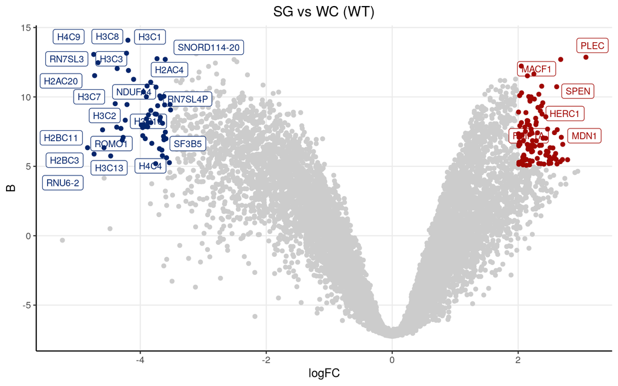

```r
upmarkers <- as.data.frame(DEGenes[DEGenes$logFC>2 & DEGenes$B>5,] )
downmarkers <- as.data.frame(DEGenes[DEGenes$logFC< -3.5 & DEGenes$B>5,] )

ggplot(data=DEGenes,
                 aes(x=logFC,
                     y=  B)) +
  geom_point(color="#CCCCCC")+
  theme_bw() +
  theme(axis.line = element_line(colour = "black"),
        panel.grid.minor = element_blank(),
        panel.border = element_blank(),
        panel.background = element_blank()) +
  ggtitle("SG vs WC (WT)")+
  theme(plot.title = element_text(hjust = 0.5)) +
  geom_label_repel(upmarkers[1:ndegs,] , mapping=aes(label=row.names(upmarkers)[1:ndegs]),size=3,point.padding=-0.5, color="#A10702",max.overlaps = 20)+
  geom_label_repel(downmarkers[1:ndegs,] , mapping=aes(label=row.names(downmarkers)[1:ndegs]),size=3,point.padding=-0.5, color="#03256C",max.overlaps = 20)+
  geom_point(data=upmarkers, aes(x=logFC, y=  B), color="#A10702")+
  geom_point(data=downmarkers, aes(x=logFC, y=  B), color="#03256C")
```

```r
wt_t <- data.frame(Gene=row.names(DEGenes), wt_t=DEGenes$t, wt_logFC=DEGenes$logFC)
```

## Volcano Plot with Transcript Length

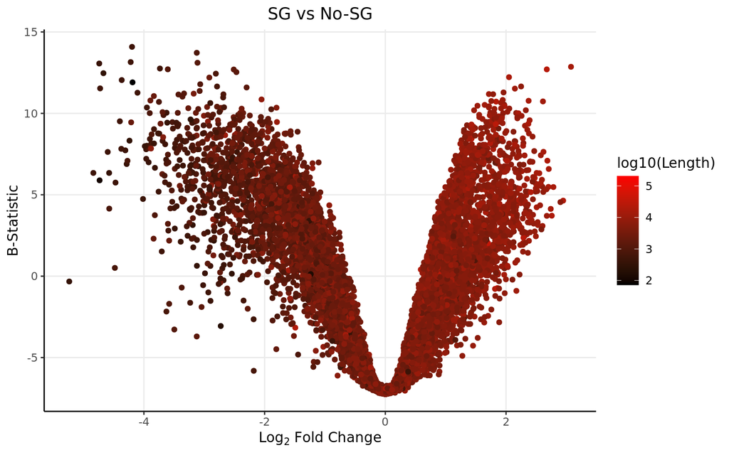

```r
DEGenes$Gene <- row.names(DEGenes)
colnames(genelength) <- c("Length","Gene")
DEGenes <- merge(DEGenes, genelength, by="Gene")

ggplot(data=DEGenes,
                 aes(x=logFC,
                     y=  B)) +
  geom_point(aes(color=log10(Length)))+
  theme_bw() +
  theme(axis.line = element_line(colour = "black"),
        panel.grid.minor = element_blank(),
        panel.border = element_blank(),
        panel.background = element_blank()) +
  ggtitle("SG vs No-SG")+ xlab(expression(Log[2] ~ Fold ~ Change)) + ylab("B-Statistic") +
  theme(plot.title = element_text(hjust = 0.5))  +
  scale_colour_gradient(low = "black", high = "red")+ theme(text=element_text(family = "Quicksand"))
```

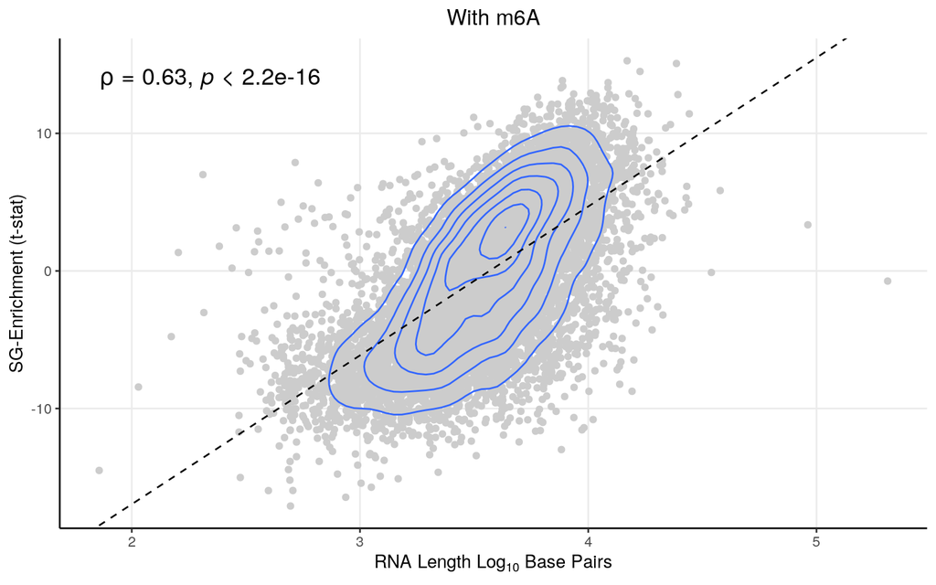

```r
smooth.SG <- lm(t~log10(Length), DEGenes)
liner.SG <- rstandard(smooth.SG)
DEGenes <-cbind(DEGenes, liner.SG)
colnames(DEGenes)[9] <- "Residuals"
row.names(DEGenes) <- DEGenes$Gene
linemarkers <- as.data.frame(DEGenes[abs(DEGenes$Residuals)>4,])

# Calculate the Spearman correlation coefficient
spearman_corr <- cor(DEGenes$t, log10(DEGenes$Length), method = "spearman")



ggplot(DEGenes, aes(y=t, x=log10(Length))) + geom_point(color="#CCCCCC", alpha=1) +   theme_bw()+ geom_density_2d()+
 ylab("SG-Enrichment (t-stat)") + xlab(expression(RNA ~ Length ~ Log[10] ~ Base ~ Pairs)) + ggtitle("With m6A")+
  theme(axis.line = element_line(colour = "black"),
        panel.grid.minor = element_blank(),
        panel.border = element_blank(),
        panel.background = element_blank()) +
  theme(plot.title = element_text(hjust = 0.5))  +
  geom_abline(slope=smooth.SG$coefficients[2], intercept = smooth.SG$coefficients[1], linetype = "dashed")+ stat_cor(method = "spearman", cor.coef.name = "rho", size=5)
```

There is a very strong lenght bias. m6A WT Stress granules are enriched in longer rnas.

# Without m6A SG vs WC

Now I will compare samples without m6A. Since the authors link m6A to SG enrichment and ALS, I focused on the ALS samples.

(Additionally, it appears the effect of m6A is very very light, but it appears to be slightly less so on ALS samples)

```r
mm <- model.matrix(~0+SampleColouring)
fitted <- lmFit(y, mm)
head(coef(fitted))
```

```
##          SampleColouringALSGCT SampleColouringALSGEX SampleColouringALWCCT
## A1BG-AS1              5.138619              5.532360              3.924289
## AAAS                  5.829701              5.560291              6.878930
## AACS                  6.067695              6.112001              5.914414
## AADAT                 3.746200              3.485048              4.549290
## AAGAB                 5.932453              6.006103              6.439615
## AAK1                  7.167454              7.381261              5.783071
##          SampleColouringALWCEX SampleColouringWTSGCT SampleColouringWTSGEX
## A1BG-AS1              4.514969              5.186189              5.786717
## AAAS                  6.912330              6.132604              5.942676
## AACS                  6.179367              6.218344              6.372440
## AADAT                 4.388452              3.756218              3.819003
## AAGAB                 6.145710              5.675714              5.670981
## AAK1                  5.912785              7.109989              7.158979
##          SampleColouringWTWCCT SampleColouringWTWCEX
## A1BG-AS1              4.175228              4.453664
## AAAS                  7.022227              6.691717
## AACS                  6.072165              6.171587
## AADAT                 4.347705              4.354719
## AAGAB                 6.299819              6.295126
## AAK1                  5.989329              6.495179
```

```r
contrastas <- makeContrasts( ((SampleColouringALSGEX))    - ((SampleColouringALWCEX))     , levels = coef(fitted))
#
tmp <- contrasts.fit(fitted, contrastas)
#
# #Correction for multiple testing
tmp <- eBayes(tmp)
#
top.table <- topTable(tmp, sort.by = "logFC", n=Inf)

DEGenes <- top.table



ndegs=20
```

## Volcano Plot

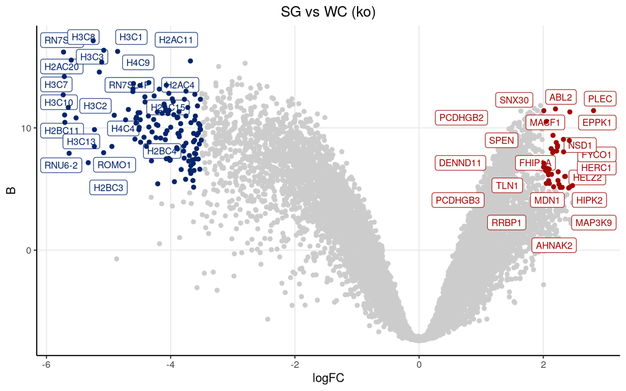

```r
upmarkers <- as.data.frame(DEGenes[DEGenes$logFC>2 & DEGenes$B>5,] )
downmarkers <- as.data.frame(DEGenes[DEGenes$logFC< -3.5 & DEGenes$B>5,] )

ggplot(data=DEGenes,
                 aes(x=logFC,
                     y=  B)) +
  geom_point(color="#CCCCCC")+
  theme_bw() +
  theme(axis.line = element_line(colour = "black"),
        panel.grid.minor = element_blank(),
        panel.border = element_blank(),
        panel.background = element_blank()) +
  ggtitle("SG vs WC (ko)")+
  theme(plot.title = element_text(hjust = 0.5)) +
  geom_label_repel(upmarkers[1:ndegs,] , mapping=aes(label=row.names(upmarkers)[1:ndegs]),size=3,point.padding=-0.5, color="#A10702",max.overlaps = 20)+
  geom_label_repel(downmarkers[1:ndegs,] , mapping=aes(label=row.names(downmarkers)[1:ndegs]),size=3,point.padding=-0.5, color="#03256C",max.overlaps = 20)+
  geom_point(data=upmarkers, aes(x=logFC, y=  B), color="#A10702")+
  geom_point(data=downmarkers, aes(x=logFC, y=  B), color="#03256C")
```

```r
nt_t <- data.frame(Gene=row.names(DEGenes), nt_t=DEGenes$t, nt_logFC=DEGenes$logFC)
```

## Volcano Plot with Transcript Length

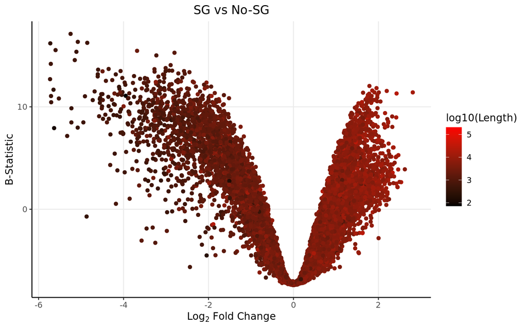

```r
DEGenes$Gene <- row.names(DEGenes)
colnames(genelength) <- c("Length","Gene")
DEGenes <- merge(DEGenes, genelength, by="Gene")

ggplot(data=DEGenes,
                 aes(x=logFC,
                     y=  B)) +
  geom_point(aes(color=log10(Length)))+
  theme_bw() +
  theme(axis.line = element_line(colour = "black"),
        panel.grid.minor = element_blank(),
        panel.border = element_blank(),
        panel.background = element_blank()) +
  ggtitle("SG vs No-SG")+ xlab(expression(Log[2] ~ Fold ~ Change)) + ylab("B-Statistic") +
  theme(plot.title = element_text(hjust = 0.5))  +
  scale_colour_gradient(low = "black", high = "red")+ theme(text=element_text(family = "Quicksand"))
```

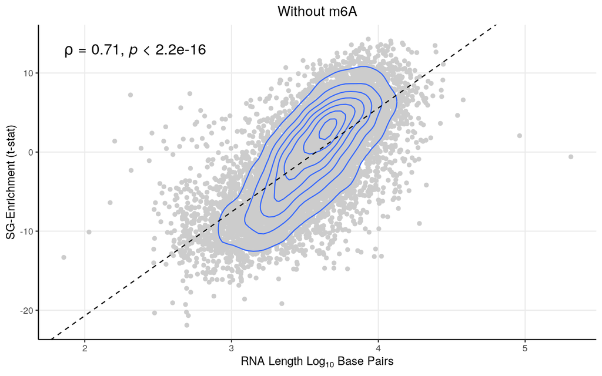

```r
smooth.SG <- lm(t~log10(Length), DEGenes)
liner.SG <- rstandard(smooth.SG)
DEGenes <-cbind(DEGenes, liner.SG)
colnames(DEGenes)[9] <- "Residuals"
row.names(DEGenes) <- DEGenes$Gene
linemarkers <- as.data.frame(DEGenes[abs(DEGenes$Residuals)>4,])

# Calculate the Spearman correlation coefficient
spearman_corr <- cor(DEGenes$t, log10(DEGenes$Length), method = "spearman")



ggplot(DEGenes, aes(y=t, x=log10(Length))) + geom_point(color="#CCCCCC", alpha=1) +   theme_bw()+ geom_density_2d()+
 ylab("SG-Enrichment (t-stat)") + xlab(expression(RNA ~ Length ~ Log[10] ~ Base ~ Pairs)) + ggtitle("Without m6A")+
  theme(axis.line = element_line(colour = "black"),
        panel.grid.minor = element_blank(),
        panel.border = element_blank(),
        panel.background = element_blank()) +
  theme(plot.title = element_text(hjust = 0.5))  +
  geom_abline(slope=smooth.SG$coefficients[2], intercept = smooth.SG$coefficients[1], linetype = "dashed")+ stat_cor(method = "spearman", cor.coef.name = "rho", size=5)
```

There is a very strong lenght bias. m6A KO Stress granules are enriched in longer rnas.

# Comparisons

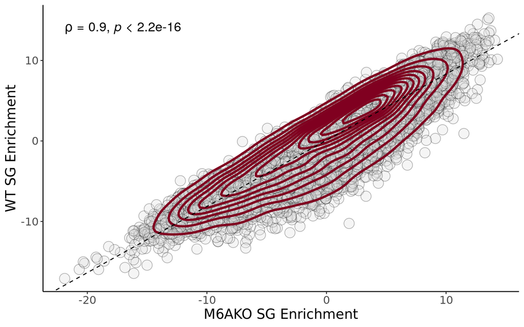

```r
m6A <- fread("~/Projects/StressGranules/Simulator/MolecularWeights_m6A.csv")[,c(1,3,4)]


wtvsnt <- merge(wt_t, nt_t, by="Gene")
colnames(m6A) <- c("Gene", "NM6A", "Ratio")
wtvsnt <- merge(wtvsnt, m6A, all.y=F, all.x=T)
wtvsnt[is.na(wtvsnt)] <- 0

smooth.SG <- lm(wt_t~(nt_t), wtvsnt)
liner.SG <- rstandard(smooth.SG)
wtvsnt <-cbind(wtvsnt, liner.SG)
colnames(wtvsnt)[8] <- "Residuals"
ogres <- wtvsnt[,c(1,8)]
#row.names(wtvsnt) <- wtvsnt$Gene
linemarkers <- as.data.frame(wtvsnt[abs(wtvsnt$Residuals)>4,])

# Calculate the Spearman correlation coefficient
spearman_corr <- cor(wtvsnt$wt_t, (wtvsnt$nt_t), method = "spearman")



ggplot(wtvsnt, aes(y=wt_t, x=(nt_t))) +
  geom_point(fill = "#DDDDDD", alpha = 0.3, size=5, shape=21, colour='black') +
  geom_density2d(color="#800020", size=1.2)  +   theme_bw()+xlab("M6AKO SG Enrichment")+
  ylab("WT SG Enrichment")+
  theme(axis.line = element_line(colour = "black"),
        panel.grid.minor = element_blank(),
        panel.border = element_blank(),
        panel.background = element_blank()) +
  theme(plot.title = element_text(hjust = 0.5)) +
  theme(text=element_text(size=15,  family="Arial MS")) + stat_cor(method = "spearman", cor.coef.name = "rho", size=5)+ theme(panel.grid.major = element_blank(), panel.grid.minor = element_blank()) +
  geom_abline(slope=smooth.SG$coefficients[2], intercept = smooth.SG$coefficients[1], linetype = "dashed")
```

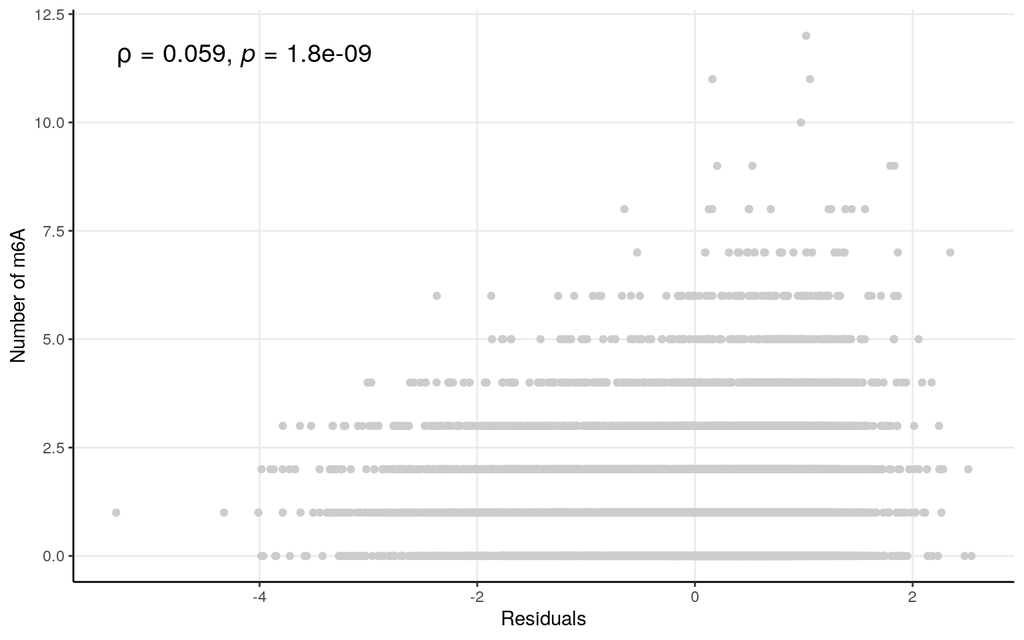

```r
ggplot(wtvsnt, aes(y=NM6A, x=(liner.SG))) + geom_point(color="#CCCCCC", alpha=1) +   theme_bw()+
 ylab("Number of m6A") + xlab("Residuals") +
  theme(axis.line = element_line(colour = "black"),
        panel.grid.minor = element_blank(),
        panel.border = element_blank(),
        panel.background = element_blank()) +
  theme(plot.title = element_text(hjust = 0.5))  + stat_cor(method = "spearman", cor.coef.name = "rho", size=5)
```

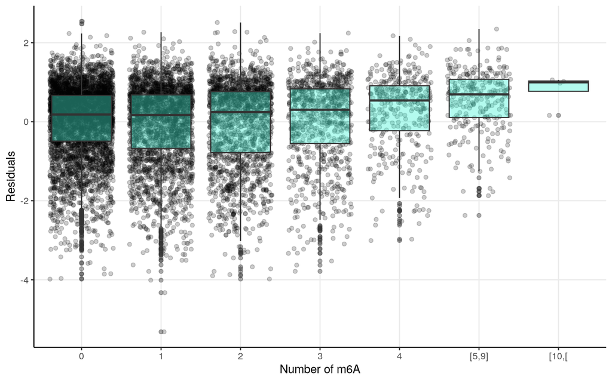

```r
wtvsnt$bins <- ifelse(wtvsnt$NM6A <= 4, wtvsnt$NM6A,
                      ifelse(wtvsnt$NM6A>=5 & wtvsnt$NM6A<=9, "[5,9]","[10,["))


wtvsnt$bins <- factor(wtvsnt$bins, levels=c(0:5, "[5,9]","[10,[" ))
ggplot(wtvsnt, aes(x=bins, y=(Residuals)))  + geom_jitter(alpha=0.2) + geom_boxplot(fill="#43F3D5", alpha=0.4) +theme_bw()+
 xlab("Number of m6A") + ylab("Residuals") +
  theme(axis.line = element_line(colour = "black"),
        panel.grid.minor = element_blank(),
        panel.border = element_blank(),
        panel.background = element_blank()) +
  theme(plot.title = element_text(hjust = 0.5))
```

```r
write.table(x = wtvsnt,
            file = "~/Projects/StressGranules/SGPAPER/M6ADATAORIG.txt", sep="\t", col.names = TRUE, row.names = TRUE, quote=FALSE)
```

Enrichment is very similar between WT and m6A KO stress granules. There does seem to be a very slight enrichment for transcripts with many m6A modifications.

# Spin-Sim

```r
goalsum_WT1 <- sum(read.counts[,7])
goalsum_KO1 <- sum(read.counts[,6])
goalsum_WT2 <- sum(read.counts[,15])
goalsum_KO2 <- sum(read.counts[,14])

colnames(genelength) <- c("Length", "Gene")


#For the new samples. Comp samples are "complex" and weight was calculate using the ratio of m6A. Simp samples simply assume that all transcripts of the same type have the same number of m6A modifications
simwt1s <- read.table("~/Projects/StressGranules/Simulator/OriginalSamples/m6A/ALSWTSG1_Simp.txt", sep = ",")[,c(1,3)]
colnames(simwt1s) <- c("Gene", "SGWT1S")
simwt2s <- read.table("~/Projects/StressGranules/Simulator/OriginalSamples/m6A/ALSWTSG2_Simp.txt", sep = ",")[,c(1,3)]
colnames(simwt2s) <- c("Gene", "SGWT2S")
simwt1c <- read.table("~/Projects/StressGranules/Simulator/OriginalSamples/m6A/ALSWTSG1_Comp.txt", sep = ",")[,c(1,3)]
colnames(simwt1c) <- c("Gene", "SGWT1C")
simwt2c <- read.table("~/Projects/StressGranules/Simulator/OriginalSamples/m6A/ALSWTSG2_Comp.txt", sep = ",")[,c(1,3)]
colnames(simwt2c) <- c("Gene", "SGWT2C")

simko1 <- read.table("~/Projects/StressGranules/Simulator/OriginalSamples/m6A/ALSKOSG1_Simp.txt", sep = ",")[,c(1,3)]
colnames(simko1) <- c("Gene", "SGKO1")
simko2 <- read.table("~/Projects/StressGranules/Simulator/OriginalSamples/m6A/ALSKOSG2_Simp.txt", sep = ",")[,c(1,3)]
colnames(simko2) <- c("Gene", "SGKO2")

simsamples <- merge(simwt1s, simwt2s, by="Gene")
#simsamples <- merge(simwt2, simwt3, by="Gene")
simsamples <- merge(simsamples, simwt1c, by="Gene")
simsamples <- merge(simsamples, simwt2c, by="Gene")
simsamples <- merge(simsamples, simko1, by="Gene")
simsamples <- merge(simsamples, simko2, by="Gene")
simsamples <- merge(simsamples, genelength, by="Gene")

simsamples <- simsamples %>%
  group_by(Gene) %>%
  slice(which.max(Length)) %>%
  ungroup()

simsamples <- as.data.frame(simsamples)

colnames(simsamples)[8] <- "Length"

simsamples$WTCounts_1 <- simsamples$SGWT1S*simsamples$Length
simsamples$WTCounts_1 <- simsamples$WTCounts_1/sum(simsamples$WTCounts_1)*goalsum_WT1
simsamples$WTCounts_2 <- simsamples$SGWT2S*simsamples$Length
simsamples$WTCounts_2 <- simsamples$WTCounts_2/sum(simsamples$WTCounts_2)*goalsum_WT2
simsamples$WTCounts_3 <- simsamples$SGWT1C*simsamples$Length
simsamples$WTCounts_3 <- simsamples$WTCounts_3/sum(simsamples$WTCounts_3)*goalsum_WT1
simsamples$WTCounts_4 <- simsamples$SGWT2C*simsamples$Length
simsamples$WTCounts_4 <- simsamples$WTCounts_4/sum(simsamples$WTCounts_4)*goalsum_WT2

simsamples$NTCounts_1 <- simsamples$SGKO1*simsamples$Length
simsamples$NTCounts_1 <- simsamples$NTCounts_1/sum(simsamples$NTCounts_1)*goalsum_KO1
simsamples$NTCounts_2 <- simsamples$SGKO2*simsamples$Length
simsamples$NTCounts_2 <- simsamples$NTCounts_2/sum(simsamples$NTCounts_2)*goalsum_KO2


simsamples <- simsamples[,c(1,9:14)]
# Use SampleColouring from metadata
SampleColouring  <- c("ALWCCT","WTWCCT","ALWCEX","WTSGEX","WTSGCT","ALSGEX","ALSGCT","WTWCEX","WTWCCT","ALWCEX","ALWCCT","WTSGEX","WTSGCT","ALSGEX","ALSGCT","WTWCEX")

OGsamples <- read.counts[,c(1,11,3,10,5,13)]
OGsamples$Gene <- row.names(OGsamples)

simandog <- merge(simsamples, OGsamples, by="Gene")
row.names(simandog) <- simandog$Gene
simandog$Gene <- NULL
```

# Filtration

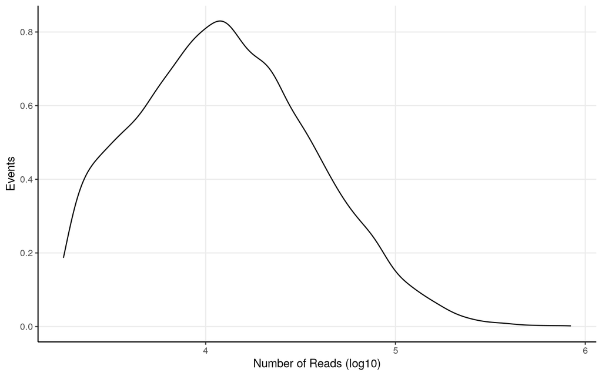

```r
alternew <- log10(rowSums(simandog))
alternew <- as.data.frame(alternew)
filterednew <- subset(simandog, alternew>3.25)
impgenes <- c(row.names(falternew))
finaltable <- simandog[row.names(simandog)%in%impgenes,]
falternew <- log10(rowSums(filterednew))
falternew <- as.data.frame(falternew)
ggplot(falternew, aes(x=falternew)) + geom_density() + theme_bw() + ylab("Events") + xlab("Number of Reads (log10)") +
  theme(axis.line = element_line(colour = "black"),
        panel.grid.minor = element_blank(),
        panel.border = element_blank(),
        panel.background = element_blank())
```

# Matrices

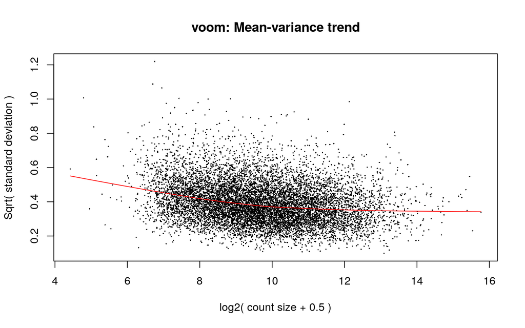

```r
sampy <- c(rep("SGWTS",2), rep("SGWTC",2), rep("KOSG",2), rep("WTWC",2),rep("KOWC",2),rep("WTSG",2))

#To be able to use Voom, we must first convert our read count table into a special DGE object.
D0 <- DGEList(finaltable)

#Then we calculate the normalization factors.
#Bear in mind this step calculates the normalization factors, but does not normalize itself.
D0 <- calcNormFactors(D0)


sampy <- sampy

#Now we do our matrix itself
mm <- model.matrix(~0+sampy)

#and now we normalize. This step also turns our counts into log2-counts per million.
y <- voom(D0, mm, plot = T)
```

## PCA

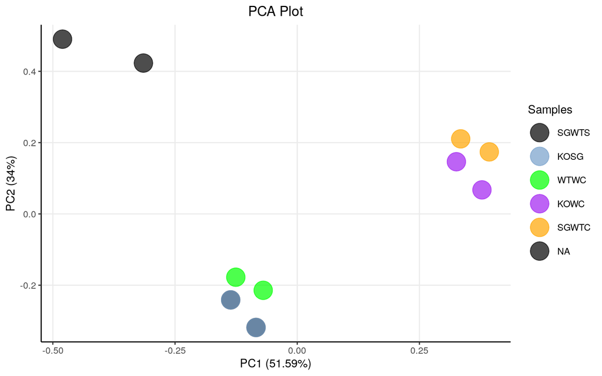

```r
#this is done to be able to do traditional PCA

sampy <- sampy
dfforpca <- y$E
dfforpca <- rbind(dfforpca, sampy)
dfforpca <- t(dfforpca)
numcol <- c(1:(ncol(dfforpca)-1))
dfforpca <- as.data.frame(dfforpca) #for some reason I can only change colum type if its a dataframe

dfforpca[ ,numcol] <- apply(dfforpca[ , numcol], 2,            # to turn our columns into numeric
                            function(x) as.numeric(as.character(x)))

#sapply(dfforpca, class) #to check class

# Or specify the factor levels in the order you want
dfforpca$sampy <- factor(dfforpca$sampy, levels = c("SGWTS", "SGWTC", "KOSG", "WTWC", "KOWC", "WTSG"))

pca_res <- prcomp(dfforpca[,numcol], scale=FALSE) #prepare the pca

#to make everything pretty
p <- autoplot(pca_res, data = dfforpca, x=1, y=2, colour = "sampy", size=8, alpha=0.7)
p <- p + theme_bw() + scale_colour_manual((name = "Samples"), values = c("black", "#769fca", "green", "purple", "orange", "black"), labels=c("SGWTS", "KOSG", "WTWC", "KOWC", "SGWTC"))
p <- p + ggtitle("PCA Plot") + theme(plot.title = element_text(hjust = 0.5)) +
  theme(axis.line = element_line(colour = "black"),
        panel.grid.minor = element_blank(),
        panel.border = element_blank(),
        panel.background = element_blank())
p
```

```r
#in case you want to see them yourself
contribs1 <- pca_res$rotation[,1]
contribs2 <- pca_res$rotation[,2]

#These are the biggest contributors to the PCA1 (right side)
(pos1genes <- sort(contribs1, decreasing=T)[1:10])
```

```
##      RNU6-2 SNORD114-20      RN7SL3     RN7SL4P      MT-ND3      H2AC20
##  0.05237052  0.04657973  0.04314876  0.04110255  0.03852182  0.03823940
##        H4C9       H3C13       ROMO1        H3C3
##  0.03747201  0.03732041  0.03711111  0.03627755
```

```r
#These are the biggest contributors to the PCA1 (left side)
(neg1genes <- sort(contribs1, decreasing=F)[1:10])
```

```
##      SH3TC2    KCNQ1OT1       KMT2D       MACF1        MDN1     HELLPAR
## -0.02682892 -0.02637009 -0.02628233 -0.02619492 -0.02535505 -0.02483265
##       HERC2     DYNC1H1      CEP250         BSN
## -0.02420933 -0.02377043 -0.02376213 -0.02343203
```

```r
#These are the biggest contributors to the PCA2 (up side)
(pos2genes <- sort(contribs2, decreasing=T)[1:10])
```

```
##  LINC00674   SVIL-AS1 JAKMIP1-DT   GTF2IP12    RPL32P3   GTF2IP20    MT-ATP8
## 0.05835286 0.05762157 0.05653564 0.05424017 0.04833349 0.04701326 0.04242530
##   CELSR1P1   SLC35E2A    ZNF767P
## 0.04178911 0.04157663 0.04130221
```

```r
#These are the biggest contributors to the PCA2 (down side)
(neg2genes <- sort(contribs2, decreasing=F)[1:10])
```

```
##     HELLPAR    KCNQ1OT1   LINC00632       MCTS1        NFIA       SMAD2
## -0.07405255 -0.04720194 -0.04125965 -0.04101908 -0.04075211 -0.03944069
##     FAM204A       CUL4B      DNAH14       CDC42
## -0.03936903 -0.03859742 -0.03851467 -0.03834837
```

## Linear Models

Now we must perform linear model fitting.

```r
fitted <- lmFit(y, mm)

head(coef(fitted))
```

```
##          sampyKOSG sampyKOWC sampySGWTC sampySGWTS sampyWTSG sampyWTWC
## A1BG-AS1  3.626601  4.417979   3.085645   3.085710  5.129079  3.856403
## AAAS      6.185391  6.821042   6.189257   6.189318  6.077386  6.812685
## AACS      6.773941  6.084797   6.536834   6.536900  6.159550  5.848088
## AADAT     3.433595  4.289287   3.597700   3.597779  3.694081  4.480884
## AAGAB     5.657082  6.049164   5.958591   5.958654  5.621859  6.371159
## AAK1      8.175503  5.815615   8.046678   8.046746  7.053287  5.713362
```

```r
#next we measure contrasts between groups (log-fold change is obtained from these fitted linear models)
contr <- makeContrasts(sampyWTSG      - sampySGWTS     , levels = colnames(coef(fitted)))

#next we estimate the contrast for each gene
tmp <- contrasts.fit(fitted, contr)


#use empirical bayes smoothing of standard erros (shrinks extreme standard erros)
tmp <- eBayes(tmp)

top.table <- topTable(tmp, sort.by = "logFC", n = Inf)

DEGenes <- top.table

ndegs <- 20
```

# WT Samples

## Volcano Plots

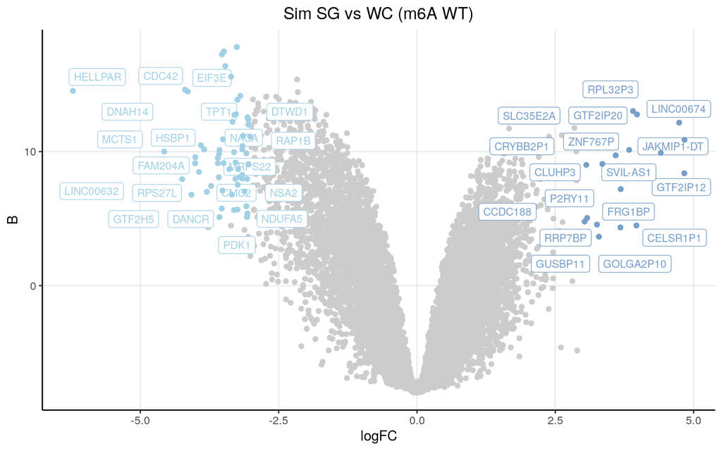

```r
upmarkers <- as.data.frame(DEGenes[DEGenes$logFC>3 & DEGenes$B>0,] )
downmarkers <- as.data.frame(DEGenes[DEGenes$logFC< -3 & DEGenes$B>5,] )

ggplot(data=DEGenes,
                 aes(x=logFC,
                     y=  B)) +
  geom_point(color="#CCCCCC")+
  theme_bw() +
  theme(axis.line = element_line(colour = "black"),
        panel.grid.minor = element_blank(),
        panel.border = element_blank(),
        panel.background = element_blank()) +
  ggtitle("Sim SG vs WC (m6A WT)")+
  theme(plot.title = element_text(hjust = 0.5)) +
  geom_label_repel(upmarkers[1:ndegs,] , mapping=aes(label=row.names(upmarkers)[1:ndegs]),size=3,point.padding=-0.5, color="#769fca",max.overlaps = 20)+
  geom_label_repel(downmarkers[1:ndegs,] , mapping=aes(label=row.names(downmarkers)[1:ndegs]),size=3,point.padding=-0.5, color="#a2d1e6",max.overlaps = 20)+
  geom_point(data=upmarkers, aes(x=logFC, y=  B), color="#769fca")+
  geom_point(data=downmarkers, aes(x=logFC, y=  B), color="#a2d1e6")
```

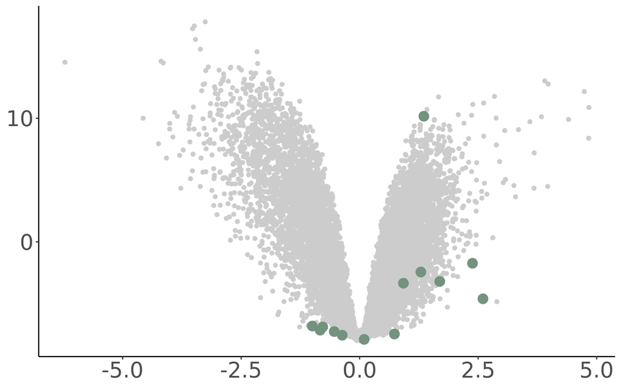

```r
simwt <- data.frame(Gene=row.names(DEGenes), simwt_t=DEGenes$t, simwt_logFC=DEGenes$logFC)
#simnt <- data.frame(Gene=row.names(DEGenes), simnt_t=DEGenes$t, simnt_logFC=DEGenes$logFC)

MitoGenes <- fread("~/MitoGenes.txt")[[1]]
MitoData <- DEGenes[rownames(DEGenes) %in% MitoGenes, ]

(m <- ggplot(data=DEGenes,
                 aes(x=logFC,
                     y=B)) +
  geom_point(color="#CCCCCC") +
  geom_point(data=MitoData, aes(x=logFC, y=B), color="#73937E", size=4) +
  ylab("") +
  xlab("") +
  theme(
    axis.line = element_line(colour = "black"),
    panel.grid.major = element_blank(),   # remove major gridlines
    panel.grid.minor = element_blank(),   # remove minor gridlines
    panel.border = element_blank(),
    panel.background = element_blank(),
    axis.title = element_blank()
  ) +
  theme(plot.title = element_text(hjust = 0.5), plot.subtitle = element_text(hjust = 0.5)) +
  theme(text=element_text(size=25, family="Arial MS")))
```

# KO Samples

```r
fitted <- lmFit(y, mm)

head(coef(fitted))
```

```
##          sampyKOSG sampyKOWC sampySGWTC sampySGWTS sampyWTSG sampyWTWC
## A1BG-AS1  3.626601  4.417979   3.085645   3.085710  5.129079  3.856403
## AAAS      6.185391  6.821042   6.189257   6.189318  6.077386  6.812685
## AACS      6.773941  6.084797   6.536834   6.536900  6.159550  5.848088
## AADAT     3.433595  4.289287   3.597700   3.597779  3.694081  4.480884
## AAGAB     5.657082  6.049164   5.958591   5.958654  5.621859  6.371159
## AAK1      8.175503  5.815615   8.046678   8.046746  7.053287  5.713362
```

```r
#next we measure contrasts between groups (log-fold change is obtained from these fitted linear models)
contr <- makeContrasts(sampyKOSG       - sampyKOWC      , levels = colnames(coef(fitted)))

#next we estimate the contrast for each gene
tmp <- contrasts.fit(fitted, contr)


#use empirical bayes smoothing of standard erros (shrinks extreme standard erros)
tmp <- eBayes(tmp)

top.table <- topTable(tmp, sort.by = "logFC", n = Inf)

DEGenes <- top.table

ndegs <- 20
```

## Volcano Plots

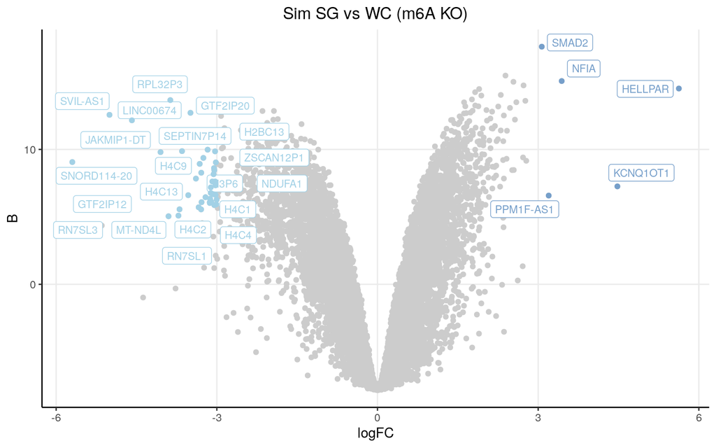

```r
upmarkers <- as.data.frame(DEGenes[DEGenes$logFC>3 & DEGenes$B>0,] )
downmarkers <- as.data.frame(DEGenes[DEGenes$logFC< -3 & DEGenes$B>5,] )

ggplot(data=DEGenes,
                 aes(x=logFC,
                     y=  B)) +
  geom_point(color="#CCCCCC")+
  theme_bw() +
  theme(axis.line = element_line(colour = "black"),
        panel.grid.minor = element_blank(),
        panel.border = element_blank(),
        panel.background = element_blank()) +
  ggtitle("Sim SG vs WC (m6A KO)")+
  theme(plot.title = element_text(hjust = 0.5)) +
  geom_label_repel(upmarkers[1:ndegs,] , mapping=aes(label=row.names(upmarkers)[1:ndegs]),size=3,point.padding=-0.5, color="#769fca",max.overlaps = 20)+
  geom_label_repel(downmarkers[1:ndegs,] , mapping=aes(label=row.names(downmarkers)[1:ndegs]),size=3,point.padding=-0.5, color="#a2d1e6",max.overlaps = 20)+
  geom_point(data=upmarkers, aes(x=logFC, y=  B), color="#769fca")+
  geom_point(data=downmarkers, aes(x=logFC, y=  B), color="#a2d1e6")
```

```r
simnt <- data.frame(Gene=row.names(DEGenes), simnt_t=DEGenes$t, simnt_logFC=DEGenes$logFC)
```

# Comparisons

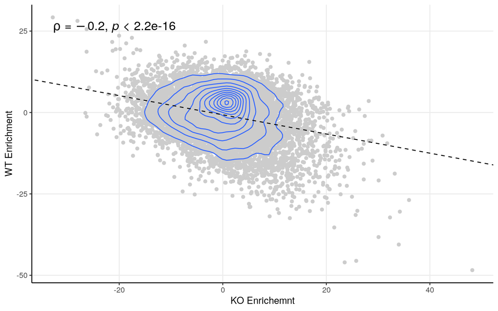

```r
wtvsnt <- merge(simwt, simnt, by="Gene")


smooth.SG <- lm(simwt_t~(simnt_t), wtvsnt)
liner.SG <- rstandard(smooth.SG)
wtvsnt <-cbind(wtvsnt, liner.SG)
colnames(wtvsnt)[6] <- "Residuals"
row.names(wtvsnt) <- wtvsnt$Gene
linemarkers <- as.data.frame(wtvsnt[abs(wtvsnt$Residuals)>4,])

# Calculate the Spearman correlation coefficient
spearman_corr <- cor(wtvsnt$simwt_t, (wtvsnt$simnt_t), method = "spearman")



ggplot(wtvsnt, aes(y=simwt_t, x=(simnt_t))) + geom_point(color="#CCCCCC", alpha=1) +   theme_bw()+ geom_density_2d()+
 ylab("WT Enrichment") + xlab("KO Enrichemnt") +
  theme(axis.line = element_line(colour = "black"),
        panel.grid.minor = element_blank(),
        panel.border = element_blank(),
        panel.background = element_blank()) +
  theme(plot.title = element_text(hjust = 0.5))  +
  geom_abline(slope=smooth.SG$coefficients[2], intercept = smooth.SG$coefficients[1], linetype = "dashed")+ stat_cor(method = "spearman", cor.coef.name = "rho", size=5)
```

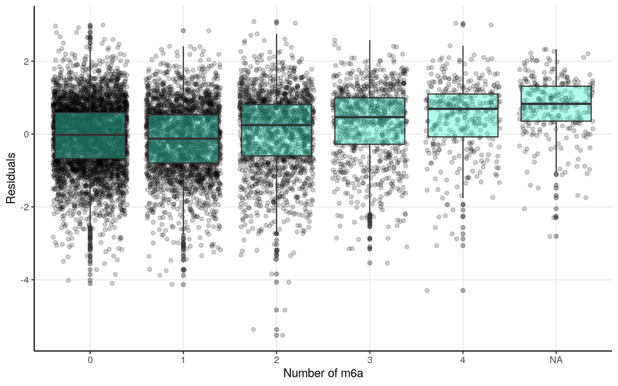

```r
colnames(m6A) <- c("Gene", "NM6A", "Ratio")
wtvsnt <- merge(wtvsnt, m6A, all.y=F, all.x=T)
wtvsnt[is.na(wtvsnt)] <- 0

wtvsnt$bins <- ifelse(wtvsnt$NM6A <= 4, wtvsnt$NM6A,
                      ifelse(wtvsnt$NM6A>=5 & wtvsnt$NM6A<=9, "[5,9]","[10,["))


wtvsnt$bins <- factor(wtvsnt$bins, levels=c(0:5, "[6,8]","[9,[" ))
ggplot(wtvsnt, aes(x=bins, y=(Residuals)))  + geom_jitter(alpha=0.2) + geom_boxplot(fill="#43F3D5", alpha=0.4) +theme_bw()+
 xlab("Number of m6a") + ylab("Residuals") +
  theme(axis.line = element_line(colour = "black"),
        panel.grid.minor = element_blank(),
        panel.border = element_blank(),
        panel.background = element_blank()) +
  theme(plot.title = element_text(hjust = 0.5))
```

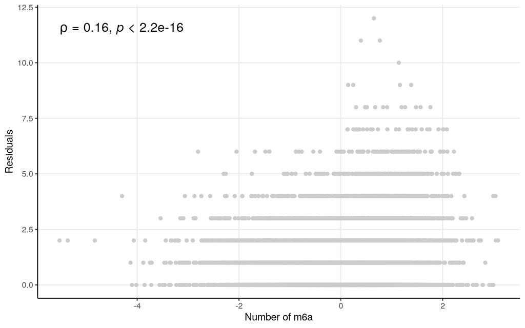

```r
ggplot(wtvsnt, aes(y=NM6A, x=(Residuals))) + geom_point(color="#CCCCCC", alpha=1) +   theme_bw()+
 xlab("Number of m6a") + ylab("Residuals") +
  theme(axis.line = element_line(colour = "black"),
        panel.grid.minor = element_blank(),
        panel.border = element_blank(),
        panel.background = element_blank()) +
  theme(plot.title = element_text(hjust = 0.5))  + stat_cor(method = "spearman", cor.coef.name = "rho", size=5)
```

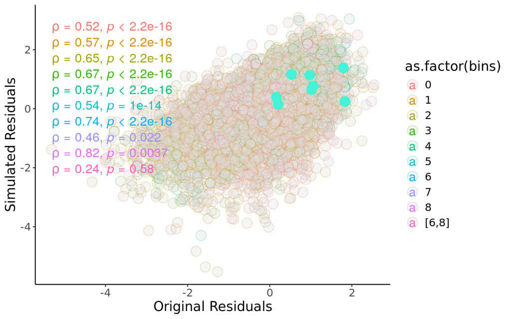

```r
simres <- wtvsnt[,c(1,6)]



resvres <- merge(ogres, simres, by="Gene")


smooth.SG <- lm(Residuals.y~(Residuals.x), resvres)
liner.SG <- rstandard(smooth.SG)
resvres <-cbind(resvres, liner.SG)
colnames(resvres)[4] <- "Residuals"
#row.names(resvres) <- resvres$Gene
linemarkers <- as.data.frame(resvres[abs(resvres$Residuals)>4,])

# Calculate the Spearman correlation coefficient
spearman_corr <- cor(resvres$Residuals.y, (resvres$Residuals.x), method = "spearman")


resvres <- merge(resvres, m6A, by="Gene", all.y=F, all.x=T)
resvres[is.na(resvres)] <- 0

resvres$bins <- ifelse(resvres$NM6A <= 8, resvres$NM6A,
                      ifelse(resvres$NM6A>=9 & resvres$NM6A<=12, "[6,8]","[9,["))


resvres$bins <- factor(resvres$bins, levels=c(0:12, "[6,8]","[9,[" ))

#resvres$bins <- resvres$NM6A
#resvres$bins <- factor(resvres$bins, levels=c(0:12))

upmarkers <- as.data.frame(resvres[resvres$NM6A>=9,] )

trial <- subset(resvres, NM6A>=5)

resvres$proxy <- resvres$NM6A*resvres$Ratio


ggplot(resvres, aes(x=(Residuals.x),y=Residuals.y, colour=as.factor(bins))) +
  geom_point(fill = "#DDDDDD", alpha = 0.3, size=5, shape=21)  +   theme_bw()+xlab("Original Residuals")+
  ylab("Simulated Residuals")+
  theme(axis.line = element_line(colour = "black"),
        panel.grid.minor = element_blank(),
        panel.border = element_blank(),
        panel.background = element_blank()) +
  theme(plot.title = element_text(hjust = 0.5)) + stat_cor(method = "spearman", cor.coef.name = "rho", size=5)+
  theme(text=element_text(size=15,  family="Arial MS")) + theme(panel.grid.major = element_blank(), panel.grid.minor = element_blank()) +
  geom_point(data=upmarkers, aes(x=Residuals.x, y=  Residuals.y), color="#43F3D5",fill="#43F3D5",alpha=1, size=5, shape=21)
```

Honestly, the effect of m6A is so light, that its hard to make any observations. In my personal opinion, its because it a very light modification (in terms of weight), and so we have trouble seeing differences in DC isolated samples.

# “Real” SG

After the spin-sim pipeline, we can then compared the original SGs to our simulated ones, which allows us to determine genes which are more or less enriched than what was expected by centrifugation alone.

```r
read.counts$Gene <- row.names(read.counts)

goalsum_WTSGEX1 <- sum(read.counts[,4])
goalsum_WTSGEX2 <- sum(read.counts[,12])
goalsum_WTSGCT1 <- sum(read.counts[,5])
goalsum_WTSGCT2 <- sum(read.counts[,13])
goalsum_ALSGEX1 <- sum(read.counts[,6])
goalsum_ALSGEX2 <- sum(read.counts[,14])
goalsum_ALSGCT1 <- sum(read.counts[,7])
goalsum_ALSGCT2 <- sum(read.counts[,15])

colnames(genelength) <- c("Length","Gene")

#For the simulated samples
SGALCT1 <- read.table("~/Projects/StressGranules/Simulator/SimulatedSamples/m6A/2026/SIM_ALCT1.txt", sep = ",", header = T)[,c(1,3)]
SGALCT1 <- na.omit(SGALCT1)
colnames(SGALCT1) <- c("Gene", "ALCT1")
SGALCT2 <- read.table("~/Projects/StressGranules/Simulator/SimulatedSamples/m6A/2026/SIM_ALCT2.txt", sep = ",", header = T)[,c(1,3)]
SGALCT2 <- na.omit(SGALCT2)
colnames(SGALCT2) <- c("Gene", "ALCT2")
SGALEX1 <- read.table("~/Projects/StressGranules/Simulator/SimulatedSamples/m6A/2026/SIM_ALEX1.txt", sep = ",", header = T)[,c(1,3)]
SGALEX1 <- na.omit(SGALEX1)
colnames(SGALEX1) <- c("Gene", "ALEX1")
SGALEX2 <- read.table("~/Projects/StressGranules/Simulator/SimulatedSamples/m6A/2026/SIM_ALEX2.txt", sep = ",", header = T)[,c(1,3)]
SGALEX2 <- na.omit(SGALEX2)
colnames(SGALEX2) <- c("Gene", "ALEX2")
SGWTEX1 <- read.table("~/Projects/StressGranules/Simulator/SimulatedSamples/m6A/2026/SIM_WTEX1.txt", sep = ",", header = T)[,c(1,3)]
SGWTEX1 <- na.omit(SGWTEX1)
colnames(SGWTEX1) <- c("Gene", "WTEX1")
SGWTEX2 <- read.table("~/Projects/StressGranules/Simulator/SimulatedSamples/m6A/2026/SIM_WTEX2.txt", sep = ",", header = T)[,c(1,3)]
SGWTEX2 <- na.omit(SGWTEX2)
colnames(SGWTEX2) <- c("Gene", "WTEX2")

SGWTWC1 <- read.table("~/Projects/StressGranules/Simulator/SimulatedSamples/m6A/2026/SIM_WTCT1.txt", sep = ",", header = T)[,c(1,3)]
SGWTWC1 <- na.omit(SGWTWC1)
colnames(SGWTWC1) <- c("Gene", "WTWC1")
SGWTWC2 <- read.table("~/Projects/StressGranules/Simulator/SimulatedSamples/m6A/2026/SIM_WTCT2.txt", sep = ",", header = T)[,c(1,3)]
SGWTWC2 <- na.omit(SGWTWC2)
colnames(SGWTWC2) <- c("Gene", "WTWC2")


#merging simulated samples up
simsamples <- merge(SGALCT1, SGALCT2, by="Gene")
simsamples <- merge(simsamples, SGALEX1, by="Gene")
simsamples <- merge(simsamples, SGALEX2, by="Gene")
simsamples <- merge(simsamples, SGWTEX1, by="Gene")
simsamples <- merge(simsamples, SGWTEX2, by="Gene")
simsamples <- merge(simsamples, SGWTWC1, by="Gene")
simsamples <- merge(simsamples, SGWTWC2, by="Gene")
simsamples <- merge(simsamples, genelength, by="Gene")

#De-Tpming old samples
simsamples$Counts_ALCT1 <- simsamples$ALCT1*simsamples$Length
simsamples$Counts_ALCT1 <- simsamples$Counts_ALCT1/sum(simsamples$Counts_ALCT1)*goalsum_ALSGCT1
simsamples$Counts_ALCT2 <- simsamples$ALCT2*simsamples$Length
simsamples$Counts_ALCT2 <- simsamples$Counts_ALCT2/sum(simsamples$Counts_ALCT2)*goalsum_ALSGCT2
simsamples$Counts_ALEX1 <- simsamples$ALEX1*simsamples$Length
simsamples$Counts_ALEX1 <- simsamples$Counts_ALEX1/sum(simsamples$Counts_ALEX1)*goalsum_ALSGEX1
simsamples$Counts_ALEX2 <- simsamples$ALEX2*simsamples$Length
simsamples$Counts_ALEX2 <- simsamples$Counts_ALEX2/sum(simsamples$Counts_ALEX2)*goalsum_ALSGEX2
simsamples$Counts_WTCT1 <- simsamples$WTWC1*simsamples$Length
simsamples$Counts_WTCT1 <- simsamples$Counts_WTCT1/sum(simsamples$Counts_WTCT1)*goalsum_WTSGCT1
simsamples$Counts_WTCT2 <- simsamples$WTWC2*simsamples$Length
simsamples$Counts_WTCT2 <- simsamples$Counts_WTCT2/sum(simsamples$Counts_WTCT2)*goalsum_WTSGCT2
simsamples$Counts_WTEX1 <- simsamples$WTEX1*simsamples$Length
simsamples$Counts_WTEX1 <- simsamples$Counts_WTEX1/sum(simsamples$Counts_WTEX1)*goalsum_WTSGEX1
simsamples$Counts_WTEX2 <- simsamples$WTEX2*simsamples$Length
simsamples$Counts_WTEX2 <- simsamples$Counts_WTEX2/sum(simsamples$Counts_WTEX2)*goalsum_WTSGEX2


simsamples <- simsamples[,c(1,11:18)]


OGsamples <- read.counts

SG_City <- merge(OGsamples, simsamples, by="Gene")
SG_City <- SG_City %>% distinct(Gene, .keep_all = TRUE)
row.names(SG_City) <- SG_City$Gene
SG_City$Gene <- NULL
```

## Filtration

### *Before Filtration*

Let us begin with the filtration. Before moving on, it is important to note that according to the authors, these RNA granules are not pure and contain several contaminants.

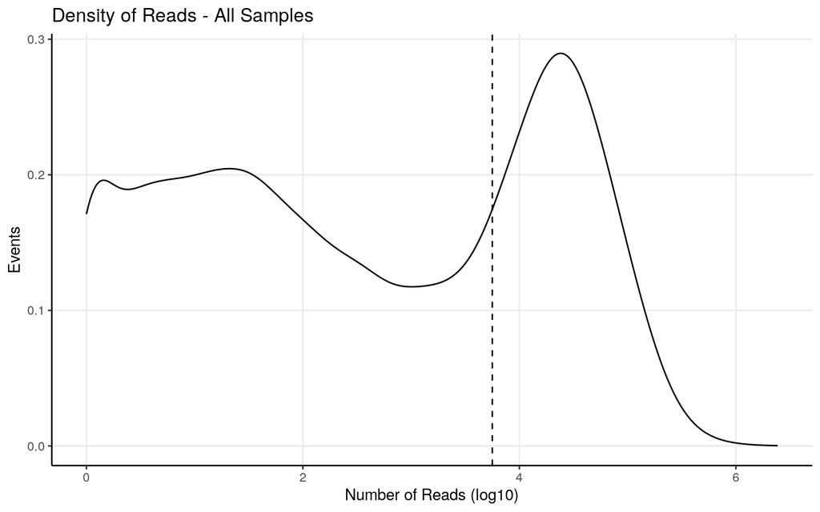

```r
alternew <- log10(rowSums(SG_City))
alternew <- as.data.frame(alternew)

ggplot(alternew, aes(x=alternew)) + geom_density() + theme_bw() + geom_vline(xintercept = 3.75, linetype = "dashed") + ylab("Events") + xlab("Number of Reads (log10)") +
  theme(axis.line = element_line(colour = "black"),
        panel.grid.minor = element_blank(),
        panel.border = element_blank(),
        panel.background = element_blank()) + ggtitle("Density of Reads - All Samples")
```

### *After Filtration*

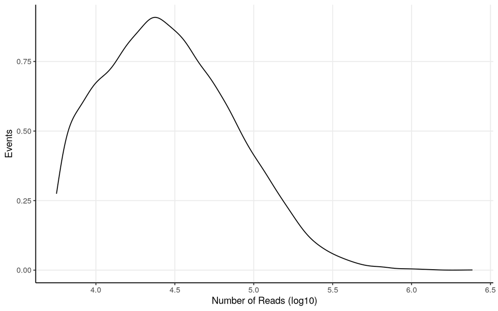

```r
filterednew <- subset(SG_City, alternew>3.75)
MitoGenes <- fread("~/MitoGenes.txt", header = FALSE)[[1]]
#after cutting, its a good idea to visualize again
falternew <- log10(rowSums(filterednew))
falternew <- as.data.frame(falternew)
ggplot(falternew, aes(x=falternew)) + geom_density() + theme_bw() + ylab("Events") + xlab("Number of Reads (log10)") +
  theme(axis.line = element_line(colour = "black"),
        panel.grid.minor = element_blank(),
        panel.border = element_blank(),
        panel.background = element_blank())
```

```r
#lets save the genes which we maintain
impgenes <- row.names(falternew)

#Now we need to select only the rows which have those genes.
finaltable <- SG_City[row.names(SG_City)%in%impgenes,]
```

## Matrices

Good! Now we can proceed by designing our matrices.

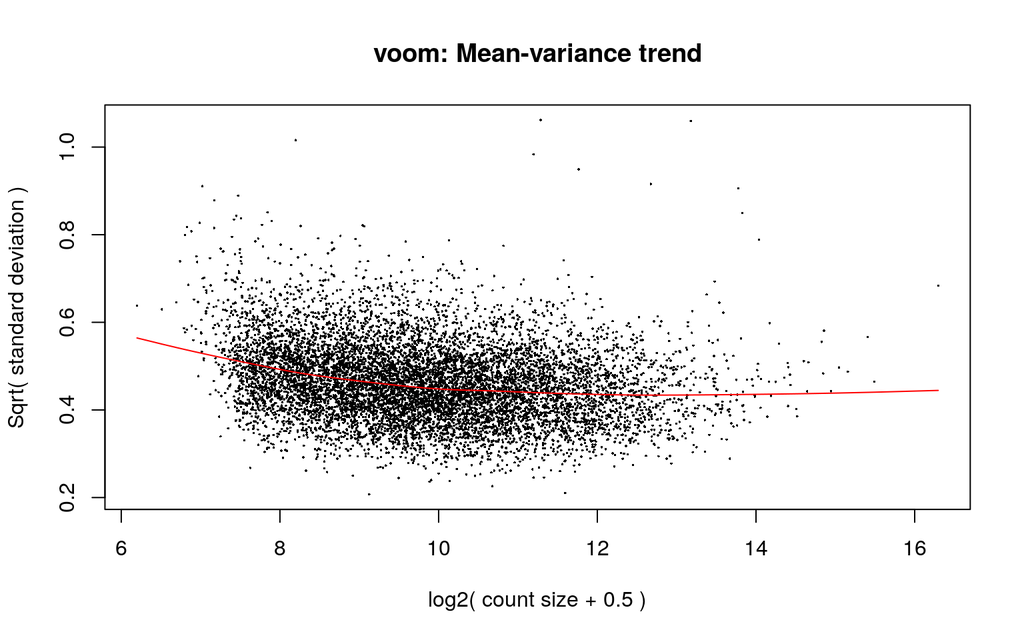

```r
#To be able to use Voom, we must first convert our read count table into a special DGE object.
D0 <- DGEList(finaltable)

#Then we calculate the normalization factors.
#Bear in mind this step calculates the normalization factors, but does not normalize itself.
D0 <- calcNormFactors(D0)

forall <- c("ALWCCT","WTWCCT","ALWCEX","WTSGEX","WTSGCT","ALSGEX","ALSGCT","WTWCEX","WTWCCT","ALWCEX","ALWCCT","WTSGEX","WTSGCT","ALSGEX","ALSGCT","WTWCEX", rep("SimALSGCT",2), rep("SimALSGEX",2), rep("SimWTSGCT",2), rep("SimWTSGEX",2))

CellType <- c("ALS","WT","ALS","WT","WT","ALS","ALS","WT","WT","ALS","ALS","WT","WT","ALS","ALS","WT", rep("ALS",4), rep("WT",4))
StressType <- c("CT","CT","KO","KO","CT","KO","CT","KO","CT","KO","CT","KO","CT","KO","CT","KO", rep("CT",2), rep("EX",2),rep("CT",2), rep("EX",2))
SampleType <- c(rep("WC",3),rep("SG",4),rep("WC",4),rep("SG",4),"WC", rep("SimSG",8))

metadata <- data.frame(Cell=CellType, Stress=StressType, Sample=SampleType)


#Now we do our matrix itself
mm <- model.matrix(~0+SampleType+CellType+StressType)

#and now we normalize. This step also turns our counts into log2-counts per million.
y <- voom(D0, mm, plot = T)
```

## Normalisation

For normalisation I convert the read counts into log2CPMs. Its a good way to visualise how the reads are.

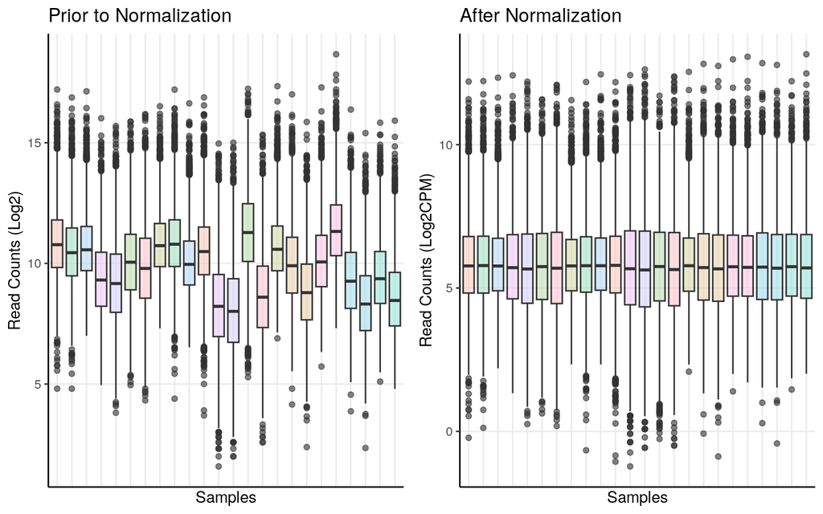

```r
dfforboxy <- finaltable
custom_palette <- qualitative_hcl(12, palette = "Pastel")
custom_palette <- sample(custom_palette,12)


orderforplots <- forall
colouring <- data.frame(Sample=colnames(dfforboxy), Types=orderforplots)
dfforboxy <- reshape2::melt(dfforboxy)
colnames(dfforboxy) <- c("Sample", "Expression")
dfforboxy <- merge(dfforboxy, colouring, by="Sample")
prenorm <- ggplot(dfforboxy, aes(x=Sample, y=(log2(Expression+1)), fill=Types)) + geom_boxplot(alpha=0.6) + theme_bw() + ylab("Read Counts (Log2)") + xlab("Samples") + scale_fill_manual(name = "Sample Type", values = (custom_palette), labels=unique(forall), breaks =unique(forall)) +
  theme(axis.line = element_line(colour = "black"),
        panel.grid.minor = element_blank(),
        panel.border = element_blank(),
        panel.background = element_blank(),
        axis.text.x=element_blank(),
        axis.ticks.x=element_blank(),
        legend.position = "None") + ggtitle("Prior to Normalization")

dfforboxy <- y$E
dfforboxy <- reshape2::melt(dfforboxy)
dfforboxy <- dfforboxy[,-1]
colnames(dfforboxy) <- c("Sample", "Expression")
dfforboxy <- merge(dfforboxy, colouring, by="Sample")
postnorm <- ggplot(dfforboxy, aes(x=Sample, y=Expression, fill=Types)) + geom_boxplot(alpha=0.6) + theme_bw() + ylab("Read Counts (Log2CPM)") + xlab("Samples") + scale_fill_manual(name = "Sample Type", values = unique(custom_palette), labels=unique(forall), breaks =unique(forall)) +
  theme(axis.line = element_line(colour = "black"),
        panel.grid.minor = element_blank(),
        panel.border = element_blank(),
        panel.background = element_blank(),
        axis.text.x=element_blank(),
        axis.ticks.x=element_blank(),
        legend.position = "None") + ggtitle("After Normalization")

ggarrange(prenorm, postnorm, nrow=1)
```

## PCA

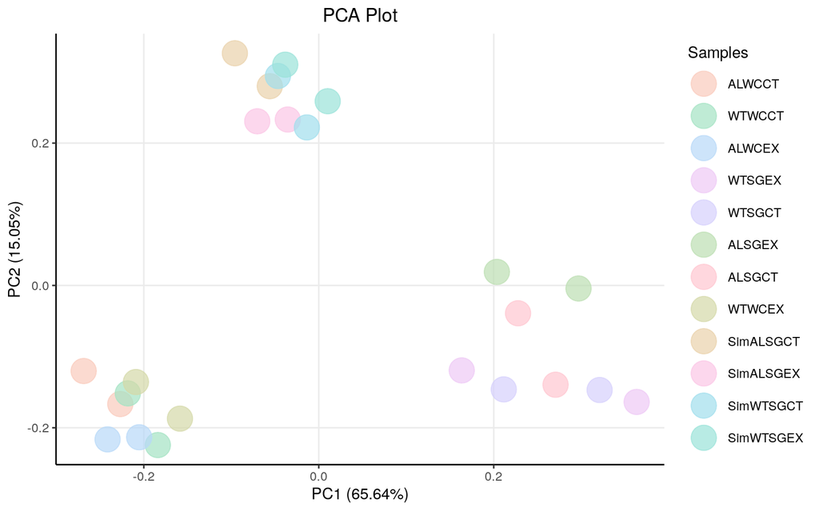

```r
#this is done to be able to do traditional PCA
dfforpca <- y$E
dfforpca <- rbind(dfforpca, forall)
row.names(dfforpca)[nrow(dfforpca)] <- "forall"
dfforpca <- t(dfforpca)
numcol <- c(1:(ncol(dfforpca)-1))
dfforpca <- as.data.frame(dfforpca) #for some reason I can only change colum type if its a dataframe

dfforpca[ ,numcol] <- apply(dfforpca[ , numcol], 2,            # to turn our columns into numeric
                            function(x) as.numeric(as.character(x)))

#sapply(dfforpca, class) #to check class

# Or specify the factor levels in the order you want
dfforpca$forall <- factor(dfforpca$forall, levels = unique(forall))

pca_res <- prcomp(dfforpca[,numcol], scale=FALSE) #prepare the pca

#to make everything pretty
p <- autoplot(pca_res, data = dfforpca, x=1, y=2, colour = "forall", size=8, alpha=0.7)
p <- p + theme_bw() + scale_colour_manual((name = "Samples"), values = custom_palette, labels=unique(forall))
p <- p + ggtitle("PCA Plot") + theme(plot.title = element_text(hjust = 0.5)) +
  theme(axis.line = element_line(colour = "black"),
        panel.grid.minor = element_blank(),
        panel.border = element_blank(),
        panel.background = element_blank())
p
```

```r
#in case you want to see them yourself
contribs1 <- pca_res$rotation[,1]
contribs2 <- pca_res$rotation[,2]

#These are the biggest contributors to the PCA1 (right side)
(pos1genes <- sort(contribs1, decreasing=T)[1:10])
```

```
##   MIR600HG       PLEC  LINC02600      KMT2D     DAB2IP     TNRC18  BAIAP2-DT
## 0.02384868 0.02312233 0.02214865 0.02144667 0.02139230 0.02123092 0.02120504
##     BAHCC1        BSN      HERC2
## 0.02091720 0.02091534 0.02077891
```

```r
#These are the biggest contributors to the PCA1 (left side)
(neg1genes <- sort(contribs1, decreasing=F)[1:10])
```

```
##      MT-ND3      H2AC20       H3C10      RN7SL3      H2BC11        H3C2
## -0.04424945 -0.04063990 -0.03935954 -0.03929999 -0.03919823 -0.03882507
##        H3C7       H3C13        H3C3       ROMO1
## -0.03854827 -0.03835755 -0.03809454 -0.03784851
```

```r
#These are the biggest contributors to the PCA2 (up side)
(pos2genes <- sort(contribs2, decreasing=T)[1:10])
```

```
##    HELLPAR   KCNQ1OT1      SMAD2   MIR23AHG      MCTS1    FAM204A       STX7
## 0.09160862 0.06409451 0.04792024 0.04265524 0.04153197 0.04068838 0.03989450
##     MRPL42     DNAH14    DNAJC10
## 0.03972738 0.03961765 0.03908876
```

```r
#These are the biggest contributors to the PCA2 (down side)
(neg2genes <- sort(contribs2, decreasing=F)[1:10])
```

```
##      CUTALP    CENPBD2P   PHKA2-AS1   BAIAP2-DT    BACE1-AS   LINC01963
## -0.04356156 -0.04104257 -0.04103240 -0.04020593 -0.03993329 -0.03964455
##   ZFHX3-AS1   TENM3-AS1       NORAD  MCM3AP-AS1
## -0.03893860 -0.03849775 -0.03831271 -0.03818921
```

## Batch Effect Correction

Looking at the PCA I considered that patient origin could be considered a batch effect. I opted to remove this batch effect.

```r
batch_cols <- c("Cell", "Stress")
metadata_cols <- c("Sample")
mmbatch <- model.matrix(reformulate(paste0("~0 + ",paste0( batch_cols,collapse = " + "))), data=metadata)
mmkeep <- model.matrix(reformulate(paste0("~0 + ",paste0( metadata_cols,collapse =  "+" ))), data=metadata)
mm <- cbind(mmkeep,mmbatch)
D0 <- DGEList(2^y$E) #senescence_normcounts
D0 <- calcNormFactors(D0)
y <- voom(D0, mm, plot = F)
```

```
## Coefficients not estimable: CellWT
```

```r
fit <- lmFit(y, mm)
```

```
## Coefficients not estimable: CellWT
```

```
## Coefficients not estimable: CellWT
```

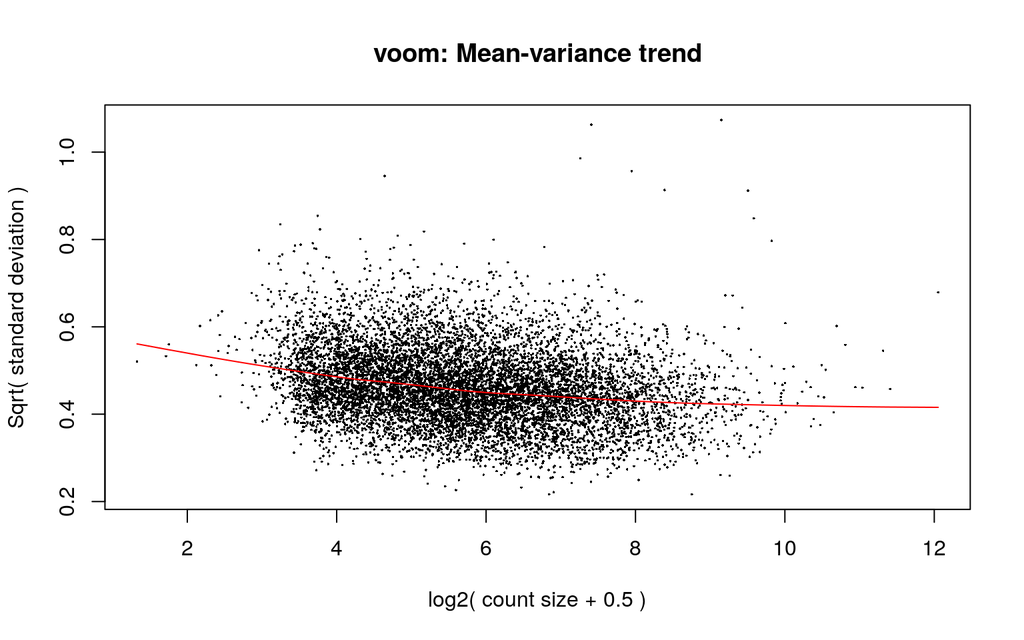

```r
beta <- fit$coefficients[,-(1:ncol(mmkeep)),drop=FALSE]
#beta <- fit$coefficients
beta[is.na(beta)] <- 0
corrcounts_v1 <- as.matrix(y$E) - beta %*% t(mmbatch)
offset <- apply(corrcounts_v1,1,min) - apply(y$E,1,min)
corrcounts_v1 <- as.data.frame(corrcounts_v1-offset)
corrcounts_v1 <- 2^corrcounts_v1
y <- voom(corrcounts_v1, mm, plot = T)
```

```r
mm <- model.matrix(~0+SampleType)

fitted <- lmFit(y, mm)

head(coef(fitted))
```

```
##          SampleTypeSG SampleTypeSimSG SampleTypeWC
## A1BG-AS1     5.320018        3.631994     4.390357
## AAAS         5.771432        6.091369     6.967148
## AACS         6.224385        5.987096     6.298800
## AADAT        3.784209        4.055609     4.677179
## AAGAB        5.809933        6.221446     6.499576
## AAK1         7.013400        7.758264     6.063692
```

```r
#next we measure contrasts between groups (log-fold change is obtained from these fitted linear models)
contr <- makeContrasts(SampleTypeSG - SampleTypeSimSG, levels = colnames(coef(fitted)))

#next we estimate the contrast for each gene
tmp <- contrasts.fit(fitted, contr)


#use empirical bayes smoothing of standard erros (shrinks extreme standard erros)
tmp <- eBayes(tmp)

top.table <- topTable(tmp, sort.by = "logFC", n = Inf)

DEGenes <- top.table

ndegs <- 20
```

## Volcano Plot

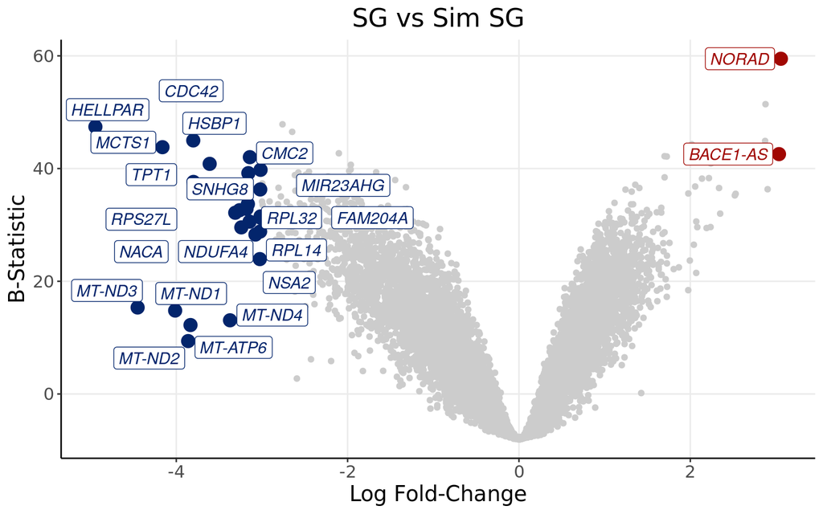

```r
write.table(x = DEGenes,
            file = "~/Projects/StressGranules/SGPAPER/RealSGs/Realm6A.txt", sep="\t", col.names = TRUE, row.names = TRUE, quote=FALSE)


upmarkers <- as.data.frame(DEGenes[DEGenes$logFC>3 & DEGenes$adj.P.Val<0.05,] )
downmarkers <- as.data.frame(DEGenes[DEGenes$logFC< -3 & DEGenes$adj.P.Val<0.05,] )

ggplot(data=DEGenes,
                 aes(x=logFC,
                     y=  B)) +
  geom_point(color="#CCCCCC")+
  theme_bw() + ylab("B-Statistic")+xlab("Log Fold-Change")+
  theme(axis.line = element_line(colour = "black"),
        panel.grid.minor = element_blank(),
        panel.border = element_blank(),
        panel.background = element_blank()) +
  ggtitle("SG vs Sim SG")+
  theme(plot.title = element_text(hjust = 0.5), plot.subtitle = element_text(hjust = 0.5)) +
  geom_point(data=upmarkers, aes(x=logFC, y=  B), color="#A10702",size=4)+
  geom_point(data=downmarkers, aes(x=logFC, y=  B), color="#03256C",size=4)+
  geom_label_repel(upmarkers[1:ndegs,] , mapping=aes(label=row.names(upmarkers)[1:ndegs]),size=4,point.padding=-0.5, color="#A10702",max.overlaps = 20, fontface="italic")+
  geom_label_repel(downmarkers[1:ndegs,] , mapping=aes(label=row.names(downmarkers)[1:ndegs]),size=4,point.padding=-0.5, color="#03256C",max.overlaps = 20, fontface="italic")+
  theme(text=element_text(size=15,  family="Arial MS"))
```

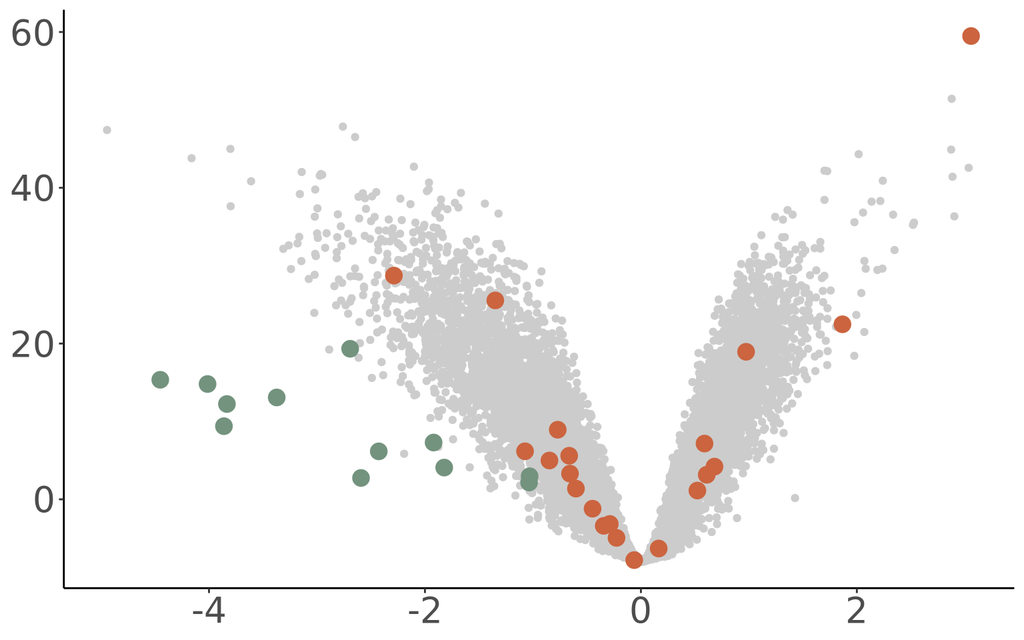

```r
MitoGenes <- fread("~/MitoGenes.txt")[[1]]
MitoData <- DEGenes[rownames(DEGenes) %in% MitoGenes, ]
NucGenes <- fread("~/rnalocate_mito_filt.csv")[[1]]
NucData <- DEGenes[rownames(DEGenes) %in% NucGenes, ]
(m <- ggplot(data=DEGenes,
                 aes(x=logFC,
                     y=B)) +
  geom_point(color="#CCCCCC") +
  geom_point(data=NucData, aes(x=logFC, y=B), color="#CB643F", size=4) +
  geom_point(data=MitoData, aes(x=logFC, y=B), color="#73937E", size=4) +
  ylab("B-Statistic") +
  xlab(expression(Log[2]~"Fold-Change")) +
  theme(
    axis.line = element_line(colour = "black"),
    panel.grid.major = element_blank(),   # remove major gridlines
    panel.grid.minor = element_blank(),   # remove minor gridlines
    panel.border = element_blank(),
    panel.background = element_blank(),
    axis.title = element_blank()
  ) +
  theme(plot.title = element_text(hjust = 0.5), plot.subtitle = element_text(hjust = 0.5)) +
  theme(text=element_text(size=25, family="Arial MS")))
```

```r
png("~/Projects/StressGranules/SGPAPER/Images/PNG/GDiTMito.png", width = 7, height=6, units = "in", res=300)
m
dev.off()
```

# MA Plot

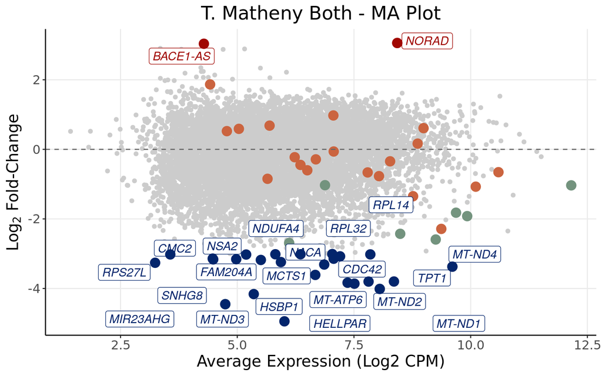

```r
# MA plot: mean expression (x) vs logFC (y), same highlighting scheme as the volcano

ggplot(data=DEGenes,
                 aes(x=AveExpr,
                     y=logFC)) +
  geom_point(color="#CCCCCC") +
  geom_point(data=MitoData, aes(x=AveExpr, y=logFC), color="#73937E", size=4) +
  geom_point(data=NucData, aes(x=AveExpr, y=logFC), color="#CB643F", size=4) +
  geom_hline(yintercept = 0, linetype="dashed", color="grey40") +
  theme_bw() + ylab(expression(Log[2]~"Fold-Change")) + xlab("Average Expression (Log2 CPM)") +
  theme(axis.line = element_line(colour = "black"),
        panel.grid.minor = element_blank(),
        panel.border = element_blank(),
        panel.background = element_blank()) +
  ggtitle("T. Matheny Both - MA Plot") +
  theme(plot.title = element_text(hjust = 0.5), plot.subtitle = element_text(hjust = 0.5)) +
  geom_label_repel(upmarkers[1:ndegs,], mapping=aes(x=AveExpr, y=logFC, label=row.names(upmarkers)[1:ndegs]), size=4, point.padding=-0.5, color="#A10702", max.overlaps=20, fontface="italic") +
  geom_label_repel(downmarkers[1:ndegs,], mapping=aes(x=AveExpr, y=logFC, label=row.names(downmarkers)[1:ndegs]), size=4, point.padding=-0.5, color="#03256C", max.overlaps=20, fontface="italic") +
  geom_point(data=upmarkers, aes(x=AveExpr, y=logFC), color="#A10702", size=4) +
  geom_point(data=downmarkers, aes(x=AveExpr, y=logFC), color="#03256C", size=4) +
  theme(text=element_text(size=15, family="Arial MS"))
```

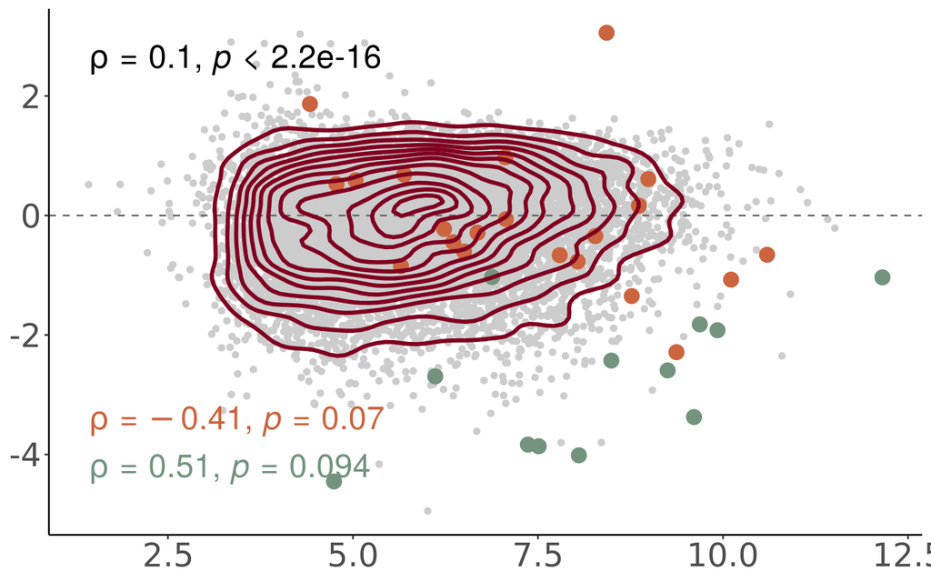

```r
# Publication-style version, stripped of axis titles, matching your "m" plot
(ma <- ggplot(data=DEGenes,
                 aes(x=AveExpr,
                     y=logFC)) +
  geom_point(color="#CCCCCC") +
  geom_point(data=MitoData, aes(x=AveExpr, y=logFC), color="#73937E", size=4) +
  geom_point(data=NucData, aes(x=AveExpr, y=logFC), color="#CB643F", size=4) +
  geom_hline(yintercept = 0, linetype="dashed", color="grey40") +
  ylab(expression(Log[2]~"Fold-Change")) +
  xlab("Average Expression (Log2 CPM)") + geom_density2d(color = "#800020", size = 1.2) + stat_cor(method = "spearman", cor.coef.name = "rho", size=7)+
  stat_cor(data = MitoData, aes(x=AveExpr, y=logFC), method = "spearman",
           cor.coef.name = "rho", size=7, color = "#73937E", label.y.npc = 0.1) +
  stat_cor(data = NucData, aes(x=AveExpr, y=logFC), method = "spearman",
           cor.coef.name = "rho", size=7, color = "#CB643F", label.y.npc = 0.2) +
  theme(
    axis.line = element_line(colour = "black"),
    panel.grid.major = element_blank(),
    panel.grid.minor = element_blank(),
    panel.border = element_blank(),
    panel.background = element_blank(),
    axis.title = element_blank()
  ) +
  theme(plot.title = element_text(hjust = 0.5), plot.subtitle = element_text(hjust = 0.5)) +
  theme(text=element_text(size=25, family="Arial MS")))
```

```r
png("~/Projects/StressGranules/SGPAPER/Images/PNG/GditMito_MA.png", width = 7, height=6, units = "in", res=300)
ma
dev.off()
```

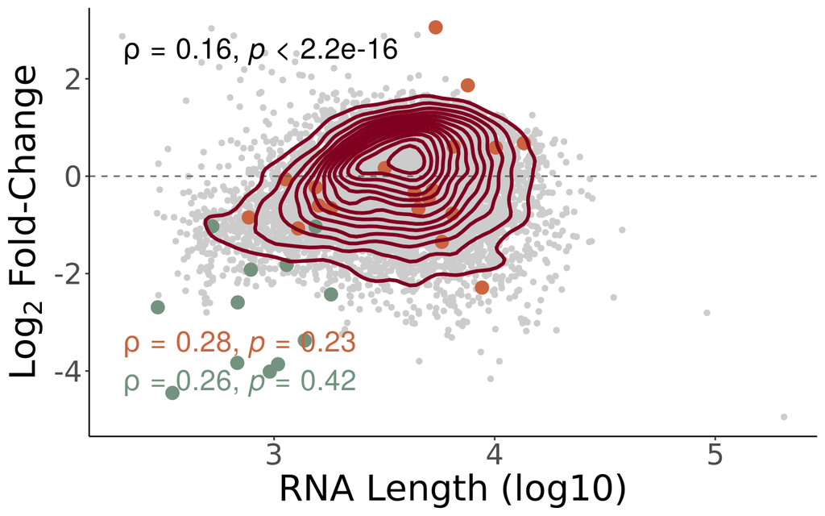

```r
MitoGenes <- fread("~/MitoGenes.txt")[[1]]

genelength <- read.csv("~/Projects/StressGranules/SG_Transcriptome/RP_Data_2021/TrimmedSamples/alignment_STAR/TranscriptLenght.txt", header=T)
genelength <- subset(genelength, Ensembl.Canonical==1)
genelength <- subset(genelength, Gene.name!="")
genelength <- genelength %>%
  group_by(Gene.name) %>%
  slice(which.max(Transcript.length..including.UTRs.and.CDS.)) %>%
  ungroup()
genelength <- genelength[,-c(2,3)]
colnames(genelength) <- c("Length", "Gene")

genelength$Cromo <- ifelse(genelength$Gene %in% MitoGenes, "Mito", "Other")

# Apply the length-based weight formula
genelength$S <- ifelse(
  genelength$Cromo == "Mito",
  (genelength$Length)^(1/3) * 3.23e-11 + 1.17e-9,   # Formula for mitochondrial RNAs
  (genelength$Length)^(1/3) * 6.09e-11 + 3.88e-10    # Formula for other RNAs
)
DEGenes$Gene <- row.names(DEGenes)
DEGenes <- merge(DEGenes, genelength, by="Gene")
MitoGenes <- fread("~/MitoGenes.txt")[[1]]
MitoData <- DEGenes[DEGenes$Gene %in% MitoGenes, ]
NucGenes <- fread("~/rnalocate_mito_filt.csv")[[1]]
NucData <- DEGenes[DEGenes$Gene %in% NucGenes, ]

# Publication-style version, stripped of axis titles, matching your "m" plot
(ma <- ggplot(data=DEGenes,
                 aes(x=log10(Length),
                     y=logFC)) +
  geom_point(color="#CCCCCC") +
  geom_point(data=MitoData, aes(x=log10(Length), y=logFC), color="#73937E", size=4) +
  geom_point(data=NucData, aes(x=log10(Length), y=logFC), color="#CB643F", size=4) +
  geom_hline(yintercept = 0, linetype="dashed", color="grey40") +
  ylab(expression(Log[2]~"Fold-Change")) + geom_density2d(color = "#800020", size = 1.2) + stat_cor(method = "spearman", cor.coef.name = "rho", size=7)+
  stat_cor(data = MitoData, aes(x=log10(Length), y=logFC), method = "spearman",
           cor.coef.name = "rho", size=7, color = "#73937E", label.y.npc = 0.1) +
  stat_cor(data = NucData, aes(x=log10(Length), y=logFC), method = "spearman",
           cor.coef.name = "rho", size=7, color = "#CB643F", label.y.npc = 0.2) +
  xlab("RNA Length (log10)") +
  theme(
    axis.line = element_line(colour = "black"),
    panel.grid.major = element_blank(),
    panel.grid.minor = element_blank(),
    panel.border = element_blank(),
    panel.background = element_blank()
  ) +
  theme(plot.title = element_text(hjust = 0.5), plot.subtitle = element_text(hjust = 0.5)) +
  theme(text=element_text(size=25, family="Arial MS")))
```

```r
png("~/Projects/StressGranules/SGPAPER/Images/PNG/GDiTMito_MA_length.png", width = 7, height=6, units = "in", res=300)
ma
dev.off()
```

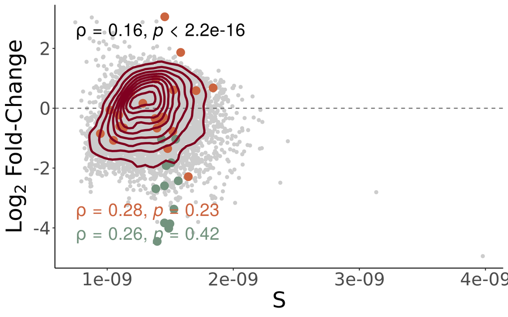

```r
# Publication-style version, stripped of axis titles, matching your "m" plot
(ma <- ggplot(data=DEGenes,
                 aes(x=(S),
                     y=logFC)) +
  geom_point(color="#CCCCCC") +
  geom_point(data=MitoData, aes(x=(S), y=logFC), color="#73937E", size=4) +
  geom_point(data=NucData, aes(x=(S), y=logFC), color="#CB643F", size=4) +
  geom_hline(yintercept = 0, linetype="dashed", color="grey40") +
  ylab(expression(Log[2]~"Fold-Change")) + geom_density2d(color = "#800020", size = 1.2) + stat_cor(method = "spearman", cor.coef.name = "rho", size=7)+
  stat_cor(data = MitoData, aes(x=S, y=logFC), method = "spearman",
           cor.coef.name = "rho", size=7, color = "#73937E", label.y.npc = 0.1) +
  stat_cor(data = NucData, aes(x=S, y=logFC), method = "spearman",
           cor.coef.name = "rho", size=7, color = "#CB643F", label.y.npc = 0.2) +
  xlab("S") +
  theme(
    axis.line = element_line(colour = "black"),
    panel.grid.major = element_blank(),
    panel.grid.minor = element_blank(),
    panel.border = element_blank(),
    panel.background = element_blank()
  ) +
  theme(plot.title = element_text(hjust = 0.5), plot.subtitle = element_text(hjust = 0.5)) +
  theme(text=element_text(size=25, family="Arial MS")))
```

```r
png("~/Projects/StressGranules/SGPAPER/Images/PNG/GDiTMito_MA_S.png", width = 7, height=6, units = "in", res=300)
ma
dev.off()
```

### Violins

```r
## Signature Violin (Mito/Nuc) - SG vs Simulated SG

library(data.table)
library(dplyr)
library(ggplot2)
library(rstatix)
# Restrict to just the SG and SimSG samples (exclude WC)
sgsim_idx <- which(SampleType %in% c("SG", "SimSG"))

expression.df <- y$E[, sgsim_idx]
cond <- factor(SampleType[sgsim_idx], levels = c("SimSG", "SG"))

custom_palette <- c(
  "SimSG" = "#EA4848",
  "SG"    = "#618264"
)

# ── 1. Gene sets already loaded earlier in the script (MitoGenes, NucGenes) ──
mito_genes_present <- MitoGenes[MitoGenes %in% rownames(expression.df)]
nuc_genes_present  <- NucGenes[NucGenes %in% rownames(expression.df)]
cat(length(mito_genes_present), "Mito genes found in expression matrix\n")
```

```
## 12 Mito genes found in expression matrix
```

```r
cat(length(nuc_genes_present), "Nuc genes found in expression matrix\n")
```

```
## 21 Nuc genes found in expression matrix
```

```r
# ── 2. Rank all genes per sample (1 = least expressed) ───────────────────────
rank_matrix <- apply(expression.df, 2, function(x) rank(x, ties.method = "average"))
rank_matrix <- as.data.frame(rank_matrix)

# ── 3. Compute a rank-sum score per sample, one gene set at a time ───────────
compute_score <- function(genes, rank_matrix, n_total) {
  colSums(rank_matrix[genes, , drop = FALSE]) / n_total
}

mito_score <- compute_score(mito_genes_present, rank_matrix, nrow(expression.df))
nuc_score  <- compute_score(nuc_genes_present, rank_matrix, nrow(expression.df))

# ── 4. Assemble plot dataframe, long format across both gene sets ────────────
score_df <- rbind(
  data.frame(Sample = colnames(expression.df), Score = as.numeric(mito_score),
             Condition = cond, GeneSet = "Mito"),
  data.frame(Sample = colnames(expression.df), Score = as.numeric(nuc_score),
             Condition = cond, GeneSet = "Nuc")
)

# ── 5. Statistics per gene set: one-way ANOVA (equivalent to t-test, 2 groups) ──
stat_labels <- score_df %>%
  group_by(GeneSet) %>%
  group_modify(~{
    aov_res  <- aov(Score ~ Condition, data = .x)
    aov_tidy <- summary(aov_res)
    p_raw  <- aov_tidy[[1]][["Pr(>F)"]][1]
    p_adj  <- p.adjust(p_raw, method = "BH")
    ss_between <- aov_tidy[[1]][["Sum Sq"]][1]
    ss_total   <- sum(aov_tidy[[1]][["Sum Sq"]])
    eta_sq     <- ss_between / ss_total
    cohens_f   <- sqrt(eta_sq / (1 - eta_sq))
    data.frame(
      label = paste0("Cohen's f = ", round(cohens_f, 3),
                      "\nadj. p = ", formatC(p_adj, format = "e", digits = 2))
    )
  })

# ── 6. Plot ───────────────────────────────────────────────────────────────────
vilsigplot <- ggplot(score_df, aes(x = Condition, y = Score, fill = Condition)) +
  geom_violin(colour = "black", alpha = 0.6, trim = FALSE) +
  geom_point(
    position = position_jitter(width = 0.1),
    alpha    = 0.7,
    size     = 1.5
  ) +
  stat_summary(fun = mean,   geom = "point", shape = 18,
               size = 3, colour = "black") +
  stat_summary(fun = median, geom = "point", shape = 17,
               size = 3, colour = "black") +
  geom_text(
    data  = stat_labels,
    aes(x = -Inf, y = Inf, label = label),
    hjust = -0.05, vjust = 1.2,
    size  = 4, fontface = "bold", lineheight = 1.1,
    inherit.aes = FALSE
  ) +
  facet_wrap(~GeneSet, scales = "free_y") +
  scale_fill_manual(values = custom_palette) +
  labs(
    x     = "Sample Type",
    y     = "Signature Score (Rank Sum)",
    title = "Mitochondrial vs Nuclear-Localized Gene Scores - SG vs Simulated SG"
  ) +
  theme_bw() +
  theme(
    plot.title      = element_text(hjust = 0.5, size = 14, face = "bold"),
    axis.text.x     = element_text(size = 12),
    strip.text      = element_text(size = 12, face = "bold"),
    legend.position = "none"
  )

png("~/Projects/StressGranules/SGPAPER/Images/PNG/GDiT_MitoSigs.png", width = 14, height=6, units = "in", res=300)
vilsigplot
dev.off()
```

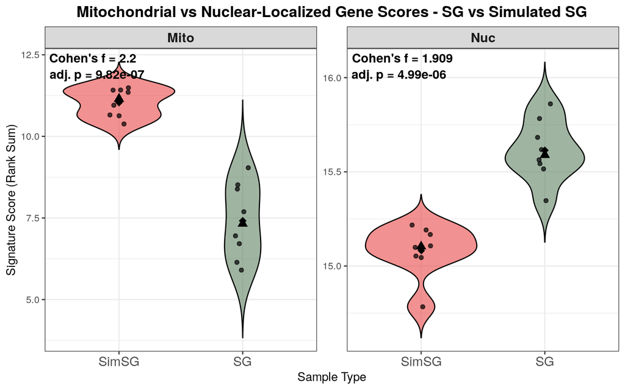

```r
vilsigplot
```

## Volcano Plot with Gene Length

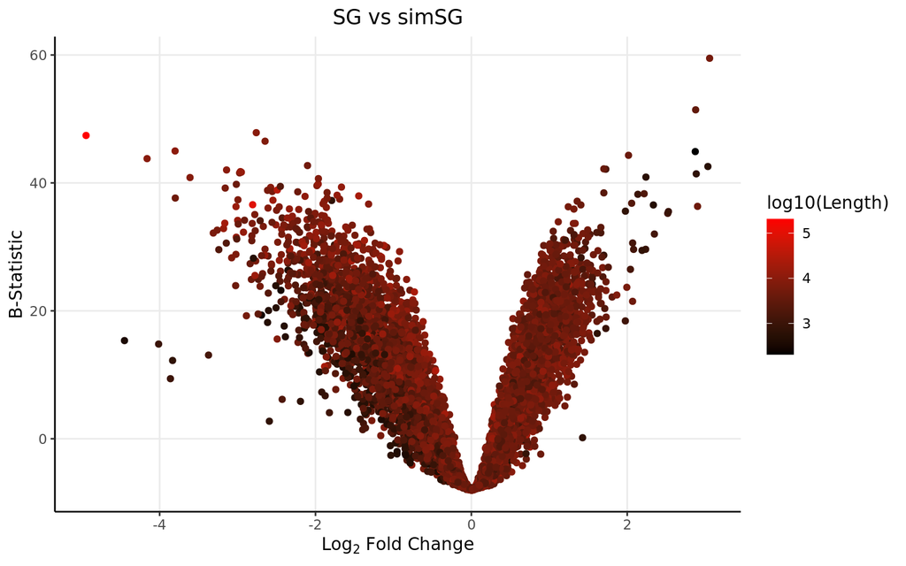

```r
ggplot(data=DEGenes,
                 aes(x=logFC,
                     y=  B)) +
  geom_point(aes(color=log10(Length)))+
  theme_bw() +
  theme(axis.line = element_line(colour = "black"),
        panel.grid.minor = element_blank(),
        panel.border = element_blank(),
        panel.background = element_blank()) +
  ggtitle("SG vs simSG")+ xlab(expression(Log[2] ~ Fold ~ Change)) + ylab("B-Statistic") +
  theme(plot.title = element_text(hjust = 0.5))  +
  scale_colour_gradient(low = "black", high = "red")+ theme(text=element_text(family = "Quicksand"))
```

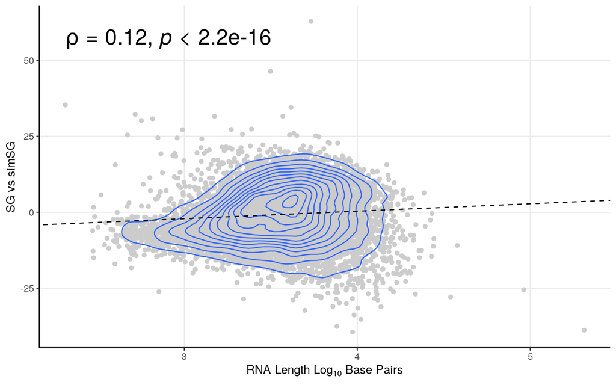

```r
smooth.SG <- lm(t~log10(Length), DEGenes)
liner.SG <- rstandard(smooth.SG)
DEGenes <-cbind(DEGenes, liner.SG)
colnames(DEGenes)[11] <- "Residuals"
row.names(DEGenes) <- DEGenes$Gene
linemarkers <- as.data.frame(DEGenes[abs(DEGenes$Residuals)>4,])

# Calculate the Spearman correlation coefficient
spearman_corr <- cor(DEGenes$t, log10(DEGenes$Length), method = "spearman")



ggplot(DEGenes, aes(y=t, x=log10(Length))) + geom_point(color="#CCCCCC", alpha=1) +   theme_bw()+ geom_density_2d()+
 ylab("SG vs simSG") + xlab(expression(RNA ~ Length ~ Log[10] ~ Base ~ Pairs)) +
  theme(axis.line = element_line(colour = "black"),
        panel.grid.minor = element_blank(),
        panel.border = element_blank(),
        panel.background = element_blank()) +
  theme(plot.title = element_text(hjust = 0.5))  +
  geom_abline(slope=smooth.SG$coefficients[2], intercept = smooth.SG$coefficients[1], linetype = "dashed")+ stat_cor(method = "spearman", cor.coef.name = "rho",size=7)
```

Corrected SGs show a minor lenght bias

## GSEA Enrichment

Now that we have our genes of interest, it would also be interesting to see what are the **altered pathways** between enriched and depleted RNAs from the stress granules. Therefore, lets perform a *Gene Set Enrichment Analysis*

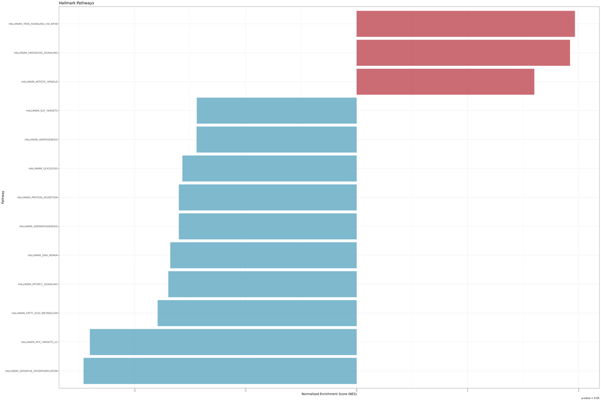

```r
#for all genes
DEGenes <- DEGenes[order(DEGenes[,4]),]
gseatool <- DEGenes[,4]
gseatool <- as.data.frame(gseatool)
colnames(gseatool)[1] <- "t"
gseatool[,2] <- DEGenes$Gene
colnames(gseatool)[2] <- "Symbol"
gseatool <- gseatool[,c(2,1)]

#for only the genes without the contamination


vectorranks <- gseatool$t
names(vectorranks) <- gseatool$Symbol


#to load our pathways
hallmarks.gs <- msigdbr(species = "Homo sapiens", collection =  "H")

hallmarks.gsets <- hallmarks.gs %>% split(x = .$gene_symbol, f = .$gs_name)

for (set in names(hallmarks.gsets)){
  hallmarks.gsets[[set]] <- toupper(hallmarks.gsets[[set]])
}

hallmarks.res <- fgsea(pathways = hallmarks.gsets,
                       stats = vectorranks)

hallmarks.res.tidy <- hallmarks.res %>%
  as_tibble() %>%
  arrange(desc(NES))

hallmarks.res.tidy %>%
  dplyr::select(-leadingEdge, -ES) %>%
  arrange(padj)

hallmark.sg.t <- hallmarks.res.tidy[,c(1,3,6)]
hallmark.sg.t <- as.data.frame(hallmark.sg.t)

#this small part is generic
thresh <- 0.05

#this one is no longer generic
data_to_plot <- hallmarks.res.tidy %>% filter(padj < thresh)

statvec <- c()
for (i in 1:nrow(data_to_plot)){
  if (data_to_plot[i,6] > 0){
    status <- "Upregulated"
  }
 else {
   status <- "Downregulated"
 }
statvec <- c(statvec, status)
}

data_to_plot$Status <- statvec

##-----HALMARK-----
ggplot(data_to_plot, aes(reorder(pathway, NES), NES)) +
  geom_col(aes(fill= Status), alpha=0.75) + scale_fill_manual(values = c("#53A2BE","#BA3B46"), name = "Regulation Status", labels = c("Downregulated", "Upregulated"), breaks = c("Downregulated", "Upregulated")) +
  coord_flip() +
  labs(x="Pathway", y="Normalized Enrichment Score (NES)",
       title= "Hallmark Pathways",
       caption = paste0("p-value < ", thresh)) + theme(plot.title = element_text(hjust = 1)) +
  theme_bw() + theme(text=element_text(family = "Quicksand")) + theme(legend.position = "none")
```

### For Mito

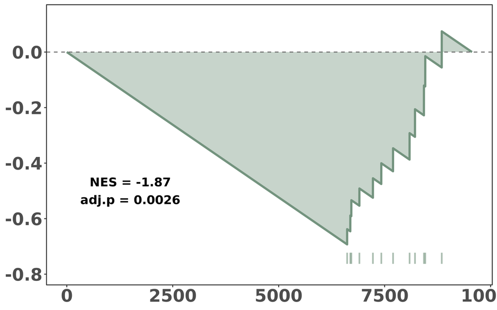

```r
# --- Rank genes by t-statistic as usual ---
DEGenes <- DEGenes[order(DEGenes[,4]),]
gseatool <- DEGenes[,4]
gseatool <- as.data.frame(gseatool)
colnames(gseatool)[1] <- "t"
gseatool[,2] <- DEGenes$Gene
colnames(gseatool)[2] <- "Symbol"
gseatool <- gseatool[,c(2,1)]
vectorranks <- gseatool$t
names(vectorranks) <- gseatool$Symbol

# --- Define MitoGenes as a custom gene set ---
MitoGenes <- fread("~/MitoGenes.txt")[[1]]
custom.gsets <- list(MitoGenes = toupper(MitoGenes))

# --- Run fgsea ---
mito.res <- fgsea(pathways = custom.gsets,
                  stats = vectorranks)

mito.plot.base <- plotEnrichment(custom.gsets[["MitoGenes"]], vectorranks)
curve.data <- mito.plot.base$data

# --- key fix: match the curve's internal descending order ---
ord <- order(vectorranks, decreasing = TRUE)
ranked.names <- names(vectorranks)[ord]
gene.positions <- which(ranked.names %in% custom.gsets[["MitoGenes"]])

rug.top    <- min(curve.data$y) - 0.03
rug.bottom <- rug.top - 0.04

y.min <- rug.bottom - 0.03
y.max <- max(curve.data$y) + 0.05

(mito.plot <- ggplot(curve.data, aes(x = x, y = y)) +
  geom_area(fill = "#73937E", alpha = 0.4) +
  geom_line(color = "#73937E", linewidth = 1.2) +
  geom_hline(yintercept = 0, linetype = "dashed", color = "grey40") +
  geom_segment(data = data.frame(x = gene.positions),
               aes(x = x, xend = x, y = rug.top, yend = rug.bottom),
               color = "#73937E", alpha = 0.6, linewidth = 0.9,
               inherit.aes = FALSE) +
  annotate("text", x = 1500, y = -0.5,
           label = paste0("NES = ", round(mito.res$NES, 2),
                          "\nadj.p = ", round(mito.res$padj, 4)),
           size = 5, family = "Arial MS", fontface = "bold") +
  coord_cartesian(ylim = c(y.min, y.max), clip = "off") +
  theme_bw() +
  theme(text = element_text(size = 25, family = "Arial MS"),
        plot.title = element_text(hjust = 0.5, face = "bold"),
        axis.title = element_blank(),
        axis.text = element_text(face = "bold"),
        panel.grid.minor = element_blank(),
        panel.grid.major = element_blank()))
```

```r
png("~/Projects/StressGranules/SGPAPER/Images/PNG/MitoGSEA_GDiT.png", width=7, height=6, units="in", res=300)
mito.plot
dev.off()
```

### For Nuc

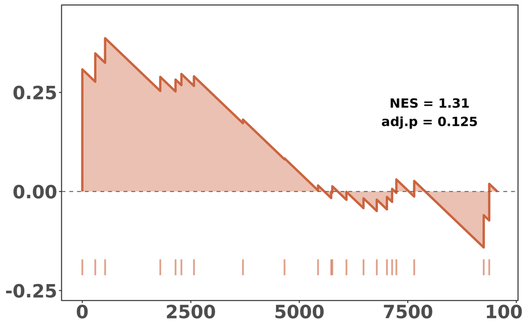

```r
# --- Rank genes by t-statistic as usual ---
DEGenes <- DEGenes[order(DEGenes[,4]),]
gseatool <- DEGenes[,4]
gseatool <- as.data.frame(gseatool)
colnames(gseatool)[1] <- "t"
gseatool[,2] <- DEGenes$Gene
colnames(gseatool)[2] <- "Symbol"
gseatool <- gseatool[,c(2,1)]
vectorranks <- gseatool$t
names(vectorranks) <- gseatool$Symbol

# --- Define MitoGenes as a custom gene set ---
MitoGenes <- fread("~/rnalocate_mito_filt.csv")[[1]]
custom.gsets <- list(MitoGenes = toupper(MitoGenes))

# --- Run fgsea ---
mito.res <- fgsea(pathways = custom.gsets,
                  stats = vectorranks)

mito.plot.base <- plotEnrichment(custom.gsets[["MitoGenes"]], vectorranks)
curve.data <- mito.plot.base$data

# --- key fix: match the curve's internal descending order ---
ord <- order(vectorranks, decreasing = TRUE)
ranked.names <- names(vectorranks)[ord]
gene.positions <- which(ranked.names %in% custom.gsets[["MitoGenes"]])

rug.top    <- min(curve.data$y) - 0.03
rug.bottom <- rug.top - 0.04

y.min <- rug.bottom - 0.03
y.max <- max(curve.data$y) + 0.05

(mito.plot <- ggplot(curve.data, aes(x = x, y = y)) +
  geom_area(fill = "#CB643F", alpha = 0.4) +
  geom_line(color = "#CB643F", linewidth = 1.2) +
  geom_hline(yintercept = 0, linetype = "dashed", color = "grey40") +
  geom_segment(data = data.frame(x = gene.positions),
               aes(x = x, xend = x, y = rug.top, yend = rug.bottom),
               color = "#CB643F", alpha = 0.6, linewidth = 0.9,
               inherit.aes = FALSE) +
  annotate("text", x = 8000, y = 0.2,
           label = paste0("NES = ", round(mito.res$NES, 2),
                          "\nadj.p = ", round(mito.res$padj, 4)),
           size = 5, family = "Arial MS", fontface = "bold") +
  coord_cartesian(ylim = c(y.min, y.max), clip = "off") +
  theme_bw() +
  theme(text = element_text(size = 25, family = "Arial MS"),
        plot.title = element_text(hjust = 0.5, face = "bold"),
        axis.title = element_blank(),
        axis.text = element_text(face = "bold"),
        panel.grid.minor = element_blank(),
        panel.grid.major = element_blank()))
```

```r
png("~/Projects/StressGranules/SGPAPER/Images/PNG/NucGSEA_Gdit.png", width=7, height=6, units="in", res=300)
mito.plot
dev.off()
```

[^1]: Disease Transcriptomics Group, Gulbenkian Institute of Molecular Medicine